# HiPIC Personality Inventory — Data Preparation and Analysis

Kevin Williams

2026-10-31

## Setup: Export Helpers

All Excel exports go through these helpers.

```r
# CHANGED: new chunk. The one workbook every export writes to -- check the file name matches yours.

HIPIC_XLSX <- path.expand("~/Documents/R/HiPIC/docs/HiPIC Exploratory.xlsx")

# CHANGED: builds feeder-sheet names such as P5VAR_MR, P5NOROT_MR, P3VAR_MR_FACETS

feeder_name <- function(PREFIX, NFACT, ROT, METHOD, FACETS = FALSE) {
  ROT_CODE  <- unname(c(varimax = "VAR", none = "NOROT", promax = "PRO", oblimin = "OBL")[ROT])
  METH_CODE <- unname(c(minres = "MR", pca = "PCA", pa = "PA", ml = "ML")[METHOD])
  if (is.na(ROT_CODE))  ROT_CODE  <- toupper(ROT)        # any other rotation: its name in capitals
  if (is.na(METH_CODE)) METH_CODE <- toupper(METHOD)
  paste0(PREFIX, NFACT, ROT_CODE, "_", METH_CODE, if (FACETS) "_FACETS")
}

# CHANGED: writes a table into a feeder sheet, starting at A1, without touching anything else.
#          Never deletes a sheet (formulas pointing at it would break); never creates a new workbook.

# CHANGED: uses openxlsx2, which preserves hand-built workbooks better than openxlsx

write_feeder <- function(DATA, SHEET, FILE = HIPIC_XLSX) {
  tryCatch({
    if (!file.exists(FILE)) stop("workbook not found: ", FILE)
    wb <- openxlsx2::wb_load(FILE)
    if (!SHEET %in% openxlsx2::wb_get_sheet_names(wb))
      wb <- openxlsx2::wb_add_worksheet(wb, SHEET)                 # new sheet: visible
    wb <- openxlsx2::wb_clean_sheet(wb, sheet = SHEET)             # clear old values
    wb <- openxlsx2::wb_add_data(wb, sheet = SHEET, x = as.data.frame(DATA),
                                 start_col = 1, start_row = 1, na.strings = "")
    openxlsx2::wb_save(wb, FILE, overwrite = TRUE)
    cat("Written to", SHEET, "in", basename(FILE), "\n")
  }, error = function(e) cat("Excel export skipped:", conditionMessage(e), "\n"))
}
```

## A. Import the SAS Datasets

Find the original SAS datasets in AllQsbyQ and import them into R for inspection. There should be one dataset for the self-reports completed by children and another for reports completed by their parents.

```r
library(haven)
library(dplyr)
library(magrittr)
library(misty)
CHILD_RAW  <- read_sas("/Volumes/FDrive/AllQsbyQ/HIPIC/allhipic_c.sas7bdat")
PARENT_RAW <- read_sas("/Volumes/FDrive/AllQsbyQ/HIPIC/allhipic_p.sas7bdat")
```

## B. Initial Data Quality Assessment

Before making any modifications, we examine the original datasets for missing values. This establishes a baseline against which subsequent exclusions and imputations can be verified.

```r
# Dimensions of the original datasets
dim(CHILD_RAW)
```

```
## [1]  79 154
```

```r
dim(PARENT_RAW)
```

```
## [1]  78 156
```

```r
# Total missing values across all variables
sum(is.na(CHILD_RAW))
```

```
## [1] 538
```

```r
sum(is.na(PARENT_RAW))
```

```
## [1] 10
```

```r
cat("The CHILD dataset contains", nrow(CHILD_RAW),
    "observations and", ncol(CHILD_RAW), "variables.\n")
```

```
## The CHILD dataset contains 79 observations and 154 variables.
```

```r
cat("The PARENT dataset contains", nrow(PARENT_RAW),
    "observations and", ncol(PARENT_RAW), "variables.\n")
```

```
## The PARENT dataset contains 78 observations and 156 variables.
```

```r
# Number of observations containing at least one missing value
sum(!complete.cases(CHILD_RAW))
```

```
## [1] 7
```

```r
sum(!complete.cases(PARENT_RAW))
```

```
## [1] 5
```

```r
library(magrittr)
library(dplyr)

CHILD_MISSING <- CHILD_RAW %>%
  mutate(N_MISSING = rowSums(is.na(pick(11:154)))) %>%
  filter(N_MISSING > 0) %>%
  select(ID4, DOE, N_MISSING)


PARENT_MISSING <- PARENT_RAW %>%
  mutate(N_MISSING = rowSums(is.na(pick(13:156)))) %>%
  filter(N_MISSING > 0) %>%
  select(ID4, DOE, N_MISSING)


#rowSums(is.na(dplyr::select(CHILD_RAW, starts_with("HC"))))
#rowSums(is.na(dplyr::select(PARENT_RAW, starts_with("HP"))))
```

## C. Remove Disqualified Observations and Impute Missing Values

```r
library(magrittr)


# excluding by subsetting from values in a datatable

# CHILD_EXCLUDE <- subset(CHILD_MISSING, N_MISSING > 3  | is.na(DOE) , select = ID4)
# PARENT_EXCLUDE <- subset(PARENT_MISSING, N_MISSING > 3 | is.na(DOE) , select = ID4)
#
#
# CHILD <-  CHILD_RAW %>% subset(!(ID4 %in% CHILD_EXCLUDE$ID4))
# PARENT <- PARENT_RAW %>% subset(!(ID4 %in% PARENT_EXCLUDE$ID4))
#


# excluding based on values in a vector


CHILD_EXCLUDE <- CHILD_MISSING %>% filter( N_MISSING >= 3 | is.na(DOE)) %>% pull(ID4)
PARENT_EXCLUDE <- PARENT_MISSING %>% filter( N_MISSING >= 3 | is.na(DOE)) %>% pull(ID4)


CHILD <-  CHILD_RAW %>% filter( !ID4 %in% CHILD_EXCLUDE)
PARENT <- PARENT_RAW %>% filter( !ID4 %in% PARENT_EXCLUDE)



#use the GROUPBY and ACROSS functions to find the CVPK/MVF mean and then apply those to questions that are missing:


CHILD <- CHILD %>%
  group_by(CVPK, MVF) %>%
  mutate(across(last_col(offset = 143):last_col(),
                function(x) {
                  ifelse(is.na(x),
                         round(mean(x, na.rm = TRUE)),
                         x)
                })) %>%
  ungroup()



PARENT <- PARENT %>%
  group_by(CVPK, MVF) %>%
  mutate(across(last_col(offset = 143):last_col(),
                function(x) {
                  ifelse(is.na(x),
                         round(mean(x, na.rm = TRUE)),
                         x)
                })) %>%
  ungroup()



#Confirm no missing values .....

sum(!complete.cases(CHILD))
```

```
## [1] 0
```

```r
sum(!complete.cases(PARENT))
```

```
## [1] 0
```

## C1. Parental (G1) and Subjet (G2) IQ Data

Since later analyses may involve adjusting for G1 or G2 IQ scores, append these scores to the CHILD and PARENT datasets so that this information is readily available.

```r
library(magrittr)


ALLIQ  <- read_sas("/Volumes/FDrive/AllQsbyQ/NEURO2017/WASI/allwasi.sas7bdat")


CHILD <- CHILD %>%  left_join(ALLIQ[ALLIQ$SP == 5 & !is.na(ALLIQ$DOE), c("ID4", "WASIEIQ")],
                                     by = c("G1ID" = "ID4")) %>% rename( G1IQ = WASIEIQ)   %>%

                   left_join (ALLIQ[ALLIQ$SP==6 & !is.na(ALLIQ$DOE), c("ID4", "WASIEIQ")],
                             by =  c("ID4" = "ID4")) %>% rename(G2IQ = WASIEIQ)

PARENT <- PARENT %>%  left_join(ALLIQ[ALLIQ$SP == 5 & !is.na(ALLIQ$DOE), c("ID4", "WASIEIQ")],
                                     by = c("G1ID" = "ID4")) %>% rename( G1IQ = WASIEIQ)   %>%

                   left_join (ALLIQ[ALLIQ$SP==6 & !is.na(ALLIQ$DOE), c("ID4", "WASIEIQ")],
                             by =  c("ID4" = "ID4")) %>% rename(G2IQ = WASIEIQ)

#investigate missingness


sum(is.na(CHILD[,"G1IQ"]))
```

```
## [1] 0
```

```r
sum(is.na(CHILD[,"G2IQ"]))
```

```
## [1] 13
```

```r
sum(is.na(PARENT[,"G1IQ"]))
```

```
## [1] 0
```

```r
sum(is.na(PARENT[,"G2IQ"]))
```

```
## [1] 17
```

```r
CHILD %>%
  mutate(MISSING_IQ = is.na(G2IQ)) %$%
  table(CVPK, MISSING_IQ)  %T>%
  print() %T>%
  { print(round((prop.table(., margin = 1)),2)) } %>%
  fisher.test()
```

```
##     MISSING_IQ
## CVPK FALSE TRUE
##    0    29    3
##    1    32   10
##     MISSING_IQ
## CVPK FALSE TRUE
##    0  0.91 0.09
##    1  0.76 0.24
```

```
##
##  Fisher's Exact Test for Count Data
##
## data:  .
## p-value = 0.1319
## alternative hypothesis: true odds ratio is not equal to 1
## 95 percent confidence interval:
##   0.6773669 18.4840703
## sample estimates:
## odds ratio
##   2.979051
```

```r
PARENT %>%
  mutate(MISSING_IQ = is.na(G2IQ)) %$%
  table(CVPK, MISSING_IQ)  %T>%
  print() %T>%
  { print(round((prop.table(., margin = 1)),2)) } %>%
  fisher.test()
```

```
##     MISSING_IQ
## CVPK FALSE TRUE
##    0    28    6
##    1    32   11
##     MISSING_IQ
## CVPK FALSE TRUE
##    0  0.82 0.18
##    1  0.74 0.26
```

```
##
##  Fisher's Exact Test for Count Data
##
## data:  .
## p-value = 0.581
## alternative hypothesis: true odds ratio is not equal to 1
## 95 percent confidence interval:
##  0.4667448 5.9730731
## sample estimates:
## odds ratio
##    1.59449
```

## D. Cohort Demographics

Ensure that the nutritional groups are reasonably balanced, and that there isn’t a statistically significant difference between them in demographic characteristics that might be used in later analyses.

```
##
## ==== Goodness of Fit (Before) ====
## # A tibble: 1 × 6
##       n statistic     p    df method          p.signif
## * <int>     <dbl> <dbl> <dbl> <chr>           <chr>
## 1    78     0.821 0.365     1 Chi-square test ns
##
## ==== Exclusions by Nutritional Group ====
##     EXCLUDED
## CVPK FALSE TRUE
##    0    34    1
##    1    43    0
##     EXCLUDED
## CVPK FALSE  TRUE
##    0  97.1   2.9
##    1 100.0   0.0
##
##  Fisher's Exact Test for Count Data
##
## data:  EXCL_TAB
## p-value = 0.4487
## alternative hypothesis: true odds ratio is not equal to 1
## 95 percent confidence interval:
##   0.00000 31.74448
## sample estimates:
## odds ratio
##          0
##
##
## ==== Goodness of Fit (After) ====
## Excluded for >= 3 missing items: 1
## # A tibble: 1 × 6
##       n statistic     p    df method          p.signif
## * <int>     <dbl> <dbl> <dbl> <chr>           <chr>
## 1    77      1.05 0.305     1 Chi-square test ns
##
## ==== Mean Age by Nutritional Group ====
##  Two-Sample t-Test
##
##   Group  n nNA     M   SD M.Diff   SE   Low  Upp    t df      p
##    0    34   0 10.69 3.07
##    1    43   0 10.76 2.71   0.06 0.66 -1.27 1.40 0.09 75 0.9262
##
## ==== Mean Parental IQ by Nutritional Group ====
##  Two-Sample t-Test
##
##   Group  n nNA     M    SD M.Diff   SE    Low   Upp     t df      p
##    0    34   0 97.41 12.81
##    1    43   0 84.16 14.40 -13.25 3.15 -19.44 -7.06 -4.21 75 0.0001
##
## ==== Percentage of Male Subjects by Nutritional Group ====
```

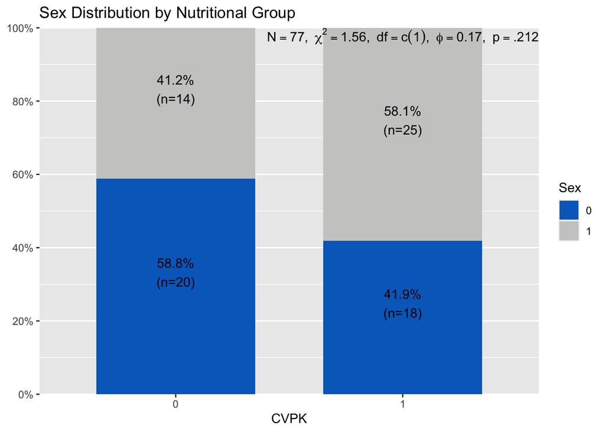

```
##     MVF
## CVPK  0  1
##    0 20 14
##    1 18 25
##     MVF
## CVPK    0    1
##    0 58.8 41.2
##    1 41.9 58.1
##
##  Pearson's Chi-squared test
##
## data:  CVPK and MVF
## X-squared = 2.1857, df = 1, p-value = 0.1393
##
##
## ==== Summary Table ====
##
##
## |                            |MAL           |CON           |p     |
## |:---------------------------|:-------------|:-------------|:-----|
## |Original N                  |43            |35            |.365  |
## |>2% of items missing, n (%) |0 (0.0%)      |1 (2.9%)      |.449  |
## |Final Analytic N            |43            |34            |.305  |
## |Testing Age, mean (SD)      |10.76 (2.71)  |10.69 (3.07)  |.926  |
## |Parental IQ, mean (SD)      |84.16 (14.40) |97.41 (12.81) |<.001 |
## |Male, n (%)                 |18 (41.9%)    |20 (58.8%)    |.139  |
```

```r
demog <-


function(DATA) {


  temp <- deparse(substitute(DATA));
  DSN <- get(paste0(temp, "_RAW"))

#  MDSN <-  get(paste0(str_sub(temp,1,1), "MISS"))

  #Goodness of Fit

  cat("\n====", "Goodness of Fit (Before)", "====\n")
  DSN %>% select(CVPK) %>% table() %>%  rstatix::chisq_test(., p= c(0.5, 0.5)) %>% print(.)


  #Missingness

  MDSN <- DSN %>%
    select(ID4, CVPK, last_col(offset=143) : last_col()) %>%
    rowwise() %>%
    mutate(MISSING = sum(is.na(c_across(last_col(offset = 143):last_col())))) %>%
    ungroup() %>%
    filter(MISSING >= 3) %>%
    select(ID4, CVPK, MISSING)


  cat("\n====", "Exclusions by Nutritional Group", "====\n")

  EXCL_TAB <- DSN %>%
    mutate(EXCLUDED = ID4 %in% pull(MDSN, ID4)) %$%
    table(CVPK, EXCLUDED)

  print(EXCL_TAB)                                         # counts
  print(round(100 * prop.table(EXCL_TAB, margin = 1), 1)) # row %: % excluded per group
  print(fisher.test(EXCL_TAB))                            # the p-value for the table






  cat("\n====", "Goodness of Fit (After)", "====\n")

  cat("Excluded for >= 3 missing items:", nrow(MDSN), "\n")


  # Dataset without Missing Obs and appended IQ values

  ANALYSIS <-  DATA %>% select(ID4, CVPK, MVF, AGEEXAM, G1IQ)

  # ANALYSIS <-  DSN %>% anti_join( MDSN[, c("ID4")], by="ID4") %>% select(ID4, CVPK, MVF, AGEEXAM)

  ANALYSIS %>% select (CVPK) %>% table() %>% rstatix::chisq_test(., p= c(0.5, 0.5)) %>% print()




  # Mean Nutritional Groups

  cat("\n====", "Mean Age by Nutritional Group", "====\n")
  ANALYSIS %>% filter(!ID4 %in% pull(MDSN, ID4))  %>%                 #PRESERVED FOR EDUC PURPOSES - ALT METHOD
    misty::test.t( AGEEXAM ~ CVPK, data = .,  descript=T, p.digits=4)


  cat("\n====", "Mean Parental IQ by Nutritional Group", "====\n")
  ANALYSIS %>% filter(!ID4 %in% pull(MDSN, ID4))  %>%                 #PRESERVED FOR EDUC PURPOSES - ALT METHOD
    misty::test.t( G1IQ ~ CVPK, data = .,  descript=T, p.digits=4)


  # Percent Male


  cat("\n====", "Percentage of Male Subjects by Nutritional Group", "====\n")
  ANALYSIS %$%
    sjPlot::plot_xtab(CVPK, MVF, margin = "row",
                      bar.pos = "stack", coord.flip = F,
                      title = "Sex Distribution by Nutritional Group",
                      axis.titles = c("CVPK"),
                      legend.title = "Sex",
                      geom.colors = c("#006cc5", "#cbcccb"),
                      show.summary = TRUE) %>% print(.)


   PCT <-
   ANALYSIS  %$%
    chisq.test(CVPK, MVF, correct = F) %>% .$observed %T>% print() %>% prop.table(margin = 1) %>% round(3) *100

   print(PCT)

   ANALYSIS %$% chisq.test(CVPK, MVF, correct = F) %>% print()



   # ---- Summary table: MAL (1) first, CON (0) second ----

  orig_n  <- table(DSN$CVPK)                     # original N per group
  final_n <- table(ANALYSIS$CVPK)                # final N per group
  excl_n  <- EXCL_TAB[, "TRUE"]                  # excluded per group
  male_n  <- table(ANALYSIS$CVPK, ANALYSIS$MVF)[, "0"]   # MVF 0 = male

  fmt_p <- function(p) ifelse(p < .001, "<.001", sub("^0", "", sprintf("%.3f", p)))

  age_txt <- sapply(c("1", "0"), function(g) {
    x <- ANALYSIS$AGEEXAM[ANALYSIS$CVPK == as.numeric(g)]
    sprintf("%.2f (%.2f)", mean(x), sd(x))
  })

  iq_text <- sapply(c("1", "0"), function(g) {
    x <- ANALYSIS$G1IQ[ANALYSIS$CVPK == as.numeric(g)]
    sprintf("%.2f (%.2f)", mean(x), sd(x))
  })

    col_for <- function(g) {
    c(orig_n[g],
      sprintf("%d (%.1f%%)", excl_n[g], 100 * excl_n[g] / orig_n[g]),
      final_n[g],
      age_txt[g],
      iq_text[g],
      sprintf("%d (%.1f%%)", male_n[g], 100 * male_n[g] / final_n[g]))
  }

  TAB <- tibble(
    ` ` = c("Original N", ">2% of items missing, n (%)", "Final Analytic N",
            "Testing Age, mean (SD)", "Parental IQ, mean (SD)", "Male, n (%)"),
    MAL = unname(col_for("1")),
    CON = unname(col_for("0")),
    p   = c(fmt_p(chisq.test(table(DSN$CVPK))$p.value),
            fmt_p(fisher.test(EXCL_TAB)$p.value),
            fmt_p(chisq.test(table(ANALYSIS$CVPK))$p.value),
            fmt_p(t.test(AGEEXAM ~ CVPK, data = ANALYSIS, var.equal = TRUE)$p.value),
            fmt_p(t.test(G1IQ ~ CVPK, data = ANALYSIS, var.equal = TRUE)$p.value),
            fmt_p(chisq.test(ANALYSIS$CVPK, ANALYSIS$MVF, correct = FALSE)$p.value)))

  cat("\n====", "Summary Table", "====\n")
  print(knitr::kable(TAB))
  invisible(TAB)


}

#   demog(PARENT)
#   demog(CHILD)



    TAB_P <- demog(PARENT)
```

```r
    TAB_C <- demog(CHILD)
```

```
##
## ==== Goodness of Fit (Before) ====
## # A tibble: 1 × 6
##       n statistic     p    df method          p.signif
## * <int>     <dbl> <dbl> <dbl> <chr>           <chr>
## 1    79      1.03 0.311     1 Chi-square test ns
##
## ==== Exclusions by Nutritional Group ====
##     EXCLUDED
## CVPK FALSE TRUE
##    0    32    3
##    1    42    2
##     EXCLUDED
## CVPK FALSE TRUE
##    0  91.4  8.6
##    1  95.5  4.5
##
##  Fisher's Exact Test for Count Data
##
## data:  EXCL_TAB
## p-value = 0.6504
## alternative hypothesis: true odds ratio is not equal to 1
## 95 percent confidence interval:
##  0.04053782 4.74947274
## sample estimates:
## odds ratio
##  0.5123411
##
##
## ==== Goodness of Fit (After) ====
## Excluded for >= 3 missing items: 5
## # A tibble: 1 × 6
##       n statistic     p    df method          p.signif
## * <int>     <dbl> <dbl> <dbl> <chr>           <chr>
## 1    74      1.35 0.245     1 Chi-square test ns
##
## ==== Mean Age by Nutritional Group ====
##  Two-Sample t-Test
##
##   Group  n nNA     M   SD M.Diff   SE   Low  Upp    t df      p
##    0    32   0 11.21 2.84
##    1    42   0 11.26 2.47   0.05 0.62 -1.21 1.31 0.07 72 0.9406
##
## ==== Mean Parental IQ by Nutritional Group ====
##  Two-Sample t-Test
##
##   Group  n nNA     M    SD M.Diff   SE    Low   Upp     t df      p
##    0    32   0 98.81 12.88
##    1    42   0 83.76 14.82 -15.05 3.29 -21.49 -8.62 -4.58 72 0.0000
##
## ==== Percentage of Male Subjects by Nutritional Group ====
```

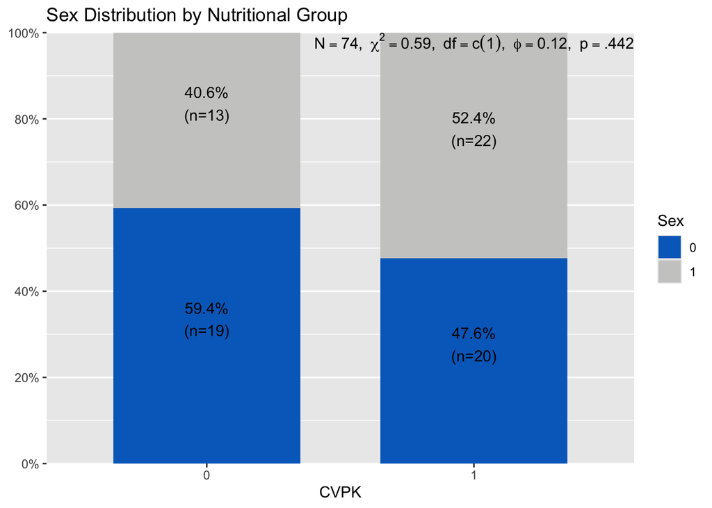

```
##     MVF
## CVPK  0  1
##    0 19 13
##    1 20 22
##     MVF
## CVPK    0    1
##    0 59.4 40.6
##    1 47.6 52.4
##
##  Pearson's Chi-squared test
##
## data:  CVPK and MVF
## X-squared = 1.007, df = 1, p-value = 0.3156
##
##
## ==== Summary Table ====
##
##
## |                            |MAL           |CON           |p     |
## |:---------------------------|:-------------|:-------------|:-----|
## |Original N                  |44            |35            |.311  |
## |>2% of items missing, n (%) |2 (4.5%)      |3 (8.6%)      |.650  |
## |Final Analytic N            |42            |32            |.245  |
## |Testing Age, mean (SD)      |11.26 (2.47)  |11.21 (2.84)  |.941  |
## |Parental IQ, mean (SD)      |83.76 (14.82) |98.81 (12.88) |<.001 |
## |Male, n (%)                 |20 (47.6%)    |19 (59.4%)    |.316  |
```

```r
saveRDS(TAB_C, "tab_child.rds")
saveRDS(TAB_P, "tab_parent.rds")
```

## E. Variable Names and Alignment

The child self-report and parent assessment versions of the HiPIC contain 144 corresponding items, but the questions are presented in different sequences. The child version distributes items across domains and facets, whereas the parent version groups related items together.

To ensure consistency in scoring, parent responses were mapped to their corresponding child-item positions using the original questionnaire content. The resulting datasets share a common item-numbering system, permitting application of De Fruyt’s scoring key to both respondent groups.

The original imported datasets were preserved without modification.

```r
HIPIC_CROSSWALK <- read.csv( "/Volumes/FDrive/AllQsbyQ/HIPIC/HiPIC_Questionnaire_Concordance_144.csv", stringsAsFactors = FALSE )

dim(HIPIC_CROSSWALK)
```

```
## [1] 144   8
```

```r
names(HIPIC_CROSSWALK)
```

```
## [1] "Q"                  "CHILD_PREPEND"      "CHILD_Q_WORDING"
## [4] "BNS_NAME_C"         "PARENT_PREPEND"     "PARENT_Q_WORDING"
## [7] "BNS_NAME_P"         "PARENT_CHILD_MATCH"
```

```r
library(sqldf)
PARENT_ALIGNED <-

sqldf("  select Q_NEW,
                concat('P', substr(CHILD_PREPEND,2)) as PARENT_PREPEND,
                PARENT_Q_WORDING,
                BNS_NAME_C,
                BNS_NAME_P,
                Q_ORIG


        from


        ( select    PARENT_PREPEND,
                    PARENT_Q_WORDING,
                    BNS_NAME_P,
                    Q as Q_ORIG

          from HIPIC_CROSSWALK )  a inner join

         (select CHILD_PREPEND,
                 BNS_NAME_C,
                 Q as Q_NEW

          from HIPIC_CROSSWALK)  b  on a.BNS_NAME_P = b.BNS_NAME_C  " )




#alternate dplyr solution


# library(dplyr)
#
# PARENT_ALIGNED <- HIPIC_CROSSWALK %>%
#   select(PARENT_Q_WORDING, BNS_NAME_P, Q_ORIG = Q) %>%
#   inner_join(
#     HIPIC_CROSSWALK %>%
#       select(CHILD_PREPEND, BNS_NAME_C, Q_NEW = Q),
#     by = c("BNS_NAME_P" = "BNS_NAME_C"),
#     keep = TRUE
#   ) %>%
#   transmute(
#     Q_NEW,
#     PARENT_PREPEND = paste0("P", substring(CHILD_PREPEND, 2)),
#     PARENT_Q_WORDING,
#     BNS_NAME_C,
#     BNS_NAME_P,
#     Q_ORIG
#   )



# With the crosswalk created and QC'd, the next step is to rename the variables in the Children's dataset to be more descriptive.



CHILD_NAMES <- with(
  HIPIC_CROSSWALK,
  paste0(
    CHILD_PREPEND, "_",
    BNS_NAME_C, "_",
    gsub(" ", "", CHILD_Q_WORDING)
  )
)



# names(CHILD)[11:154] <- CHILD_NAMES
# names(CHILD)[tail(seq_along(CHILD), 144)] <- CHILD_NAMES

START <- match("TALK", names(CHILD))
names(CHILD)[ START:(START+143)]  <- CHILD_NAMES


CHILD_NAMES
```

```
##   [1] "C1_TALK_Italktopeopleeasily"
##   [2] "C2_HURT_Iamquicktohavemyfeelingshurt"
##   [3] "C3_BEST_Iwanttobeamongthebest"
##   [4] "C4_PANIC_Iamquicktopanic"
##   [5] "C5_IMAGINE_Ihavelittleimagination"
##   [6] "C6_EXPERIENCE_Itellmyownexperiencesuninvited"
##   [7] "C7_OFFENDED_Iamquicktobeoffended"
##   [8] "C8_LEAVETHINGS_Ileaveeverythinglyingaround"
##   [9] "C9_INSECURE_Ihavefewinsecurities"
##  [10] "C10_KNOWDETAIL_Iwanttoknowthelittledetailsofthings"
##  [11] "C11_LAUGH_Igolaughingthroughlife"
##  [12] "C12_POLITE_Irespectrulesofpoliteness"
##  [13] "C13_OCCUPYSELF_Icanoccupymyselfforalongtime"
##  [14] "C14_CATCHON_Icatchonwithhalfanexplanation"
##  [15] "C15_ONMOVE_Iamconstantlyonthemove"
```

[output cut: 129 more lines]

```r
#repeat the process for the Parents dataset



PARENT_NAMES <- with(
  PARENT_ALIGNED,
  paste0(
    PARENT_PREPEND, "_",
    BNS_NAME_C, "_",
    gsub(" ", "", PARENT_Q_WORDING)
  )
)




# names(PARENT)[13:156] <- PARENT_NAMES


START <- match("TALK", names(PARENT))
names(PARENT)[ START:(START+143)]  <- PARENT_NAMES




#validation
length(CHILD_NAMES)
```

```
## [1] 144
```

```r
length(unique(CHILD_NAMES))
```

```
## [1] 144
```

```r
length(PARENT_NAMES)
```

```
## [1] 144
```

```r
length(unique(PARENT_NAMES))
```

```
## [1] 144
```

## F. Reverse Scoring and Facet Scores

The scoring key provided by DeFruyt identifies the questions along each domain/facet that require reverse scoring.

```r
#Items identified as requiring reverse scoring in DeFruyt's key (questions are moving in opposite directions from other questions in the instrument):


REVERSE_ITEMS <- c(  1, 5, 8, 16, 17, 20, 27, 35, 37, 41,
                     42, 44, 49, 50, 53, 55, 60, 62, 63, 79,
                     80, 84, 87, 89, 99, 103, 107, 110, 120,
                     121, 122, 124, 129, 138, 139, 143  )



# use an ACROSS statement to compute a reverse score for the items in the REVERSE_ITEMS vector


CHILD_REVERSED <-CHILD %>% mutate(across( starts_with( paste0("C", REVERSE_ITEMS, "_")),
                    function(x) 6 - x )
                        )

PARENT_REVERSED <-PARENT %>% mutate(across( starts_with( paste0("P", REVERSE_ITEMS, "_")),
              function(x) 6 - x )
                  )




write.csv(PARENT_REVERSED,
          "PARENT_REVERSED.csv",
          row.names = FALSE)


write.csv(PARENT,
          "PARENT.csv",
          row.names = FALSE)


# Assign questions for each facet to unique vector

#Emotional Stability

ES_ANX <- c(4, 22, 40, 58, 76, 94, 112, 130)
ES_CON <- c(9, 27, 45, 63, 81, 99, 117, 135)

#Extraversion

EX_ENE <- c(15, 33, 51, 69, 87, 105, 123, 141)
EX_EXP <- c(6, 24, 42, 60, 78, 96, 114, 132)
EX_OPT <- c(11,29, 47,65, 83, 101, 119, 137)
EX_SHY <- c(1, 19, 37, 55, 73, 91, 109, 127)

#Imagination

IM_CRE <- c(5, 23, 41, 59, 77, 95, 113, 131)
IM_INT <- c(14, 32, 50, 68,86, 104, 122, 140)
IM_CUR <- c(10, 28, 46, 64, 82, 100, 118, 136)

#Benevolence

BE_ALT <- c(18, 36, 54, 72, 90, 108, 126, 144)
BE_DOM <- c(16, 34, 52, 70, 88, 106, 124, 142)
BE_EGO <- c(2, 20, 38, 56, 74, 92, 110, 128)
BE_COM <- c(12, 30, 48, 66, 84, 102, 120, 138)
BE_IRR <- c(7, 25, 43, 61, 79, 97, 115, 133)

#Conscientiousness

CO_CNC <- c(13, 31, 49, 67, 85, 103, 121, 139)
CO_PER <- c(17, 35, 53, 71, 89, 107, 125, 143)
CO_ORD <- c(8, 26, 44, 62, 80, 98, 116, 134)
CO_ACH <- c(3, 21, 39, 57, 75, 93, 111, 129)





# Compute facets & domain scores based on DeFruyt's formulas


# Since code is similar except for the files called, the files created and the variable prefix, consider a simple function  -not quite a SAS do loop, but still more efficient than duplicate blocks of code


#SCORE HIPIC FUNCTION



score_hipic <- function(DATA, PREFIX) {

  DATA %>%
  mutate(
    ES_ANX = rowSums( select(., starts_with(paste0(PREFIX, ES_ANX, "_"))) ),
    ES_CON = rowSums( select(., starts_with(paste0(PREFIX, ES_CON, "_"))) ),

        # Emotional Stability
        ES = (48 - ES_ANX) + ES_CON,

    EX_ENE = rowSums( select(., starts_with(paste0(PREFIX, EX_ENE, "_"))) ),
    EX_EXP = rowSums( select(., starts_with(paste0(PREFIX, EX_EXP, "_"))) ),
    EX_OPT = rowSums( select(., starts_with(paste0(PREFIX, EX_OPT, "_"))) ),
    EX_SHY = rowSums( select(., starts_with(paste0(PREFIX, EX_SHY, "_"))) ),

      # Extraversion
      EX = EX_ENE + EX_EXP + EX_OPT + (48 - EX_SHY),


    IM_CRE = rowSums( select(., starts_with(paste0(PREFIX, IM_CRE, "_"))) ),
    IM_INT = rowSums( select(., starts_with(paste0(PREFIX, IM_INT, "_"))) ),
    IM_CUR = rowSums( select(., starts_with(paste0(PREFIX, IM_CUR, "_"))) ),

      # Imagination
      IM = IM_CRE + IM_INT + IM_CUR,


    BE_ALT = rowSums( select(., starts_with(paste0(PREFIX, BE_ALT, "_"))) ),
    BE_DOM = rowSums( select(., starts_with(paste0(PREFIX, BE_DOM, "_"))) ),
    BE_EGO = rowSums( select(., starts_with(paste0(PREFIX, BE_EGO, "_"))) ),
    BE_COM = rowSums( select(., starts_with(paste0(PREFIX, BE_COM, "_"))) ),
    BE_IRR = rowSums( select(., starts_with(paste0(PREFIX, BE_IRR, "_"))) ),

      # Benevolence
      BE = BE_ALT + (48 - BE_DOM) + (48 - BE_EGO) + BE_COM + (48 - BE_IRR),

    CO_CNC = rowSums( select(., starts_with(paste0(PREFIX, CO_CNC, "_"))) ),
    CO_PER = rowSums( select(., starts_with(paste0(PREFIX, CO_PER, "_"))) ),
    CO_ORD = rowSums( select(., starts_with(paste0(PREFIX, CO_ORD, "_"))) ),
    CO_ACH = rowSums( select(., starts_with(paste0(PREFIX, CO_ACH, "_"))) ),

    # Conscientiousness
    CO = CO_CNC + CO_PER + CO_ORD + CO_ACH


  ) %>% select( SG, ID4:MVF, AGEEXAM, c(G1IQ,G2IQ), ES_ANX:CO)

}





CHILD_SCORED  <- score_hipic(CHILD_REVERSED, "C")
PARENT_SCORED <- score_hipic(PARENT_REVERSED, "P")








write.csv(PARENT_SCORED,
          "QC",
          row.names = FALSE)








# Prepare a Facets Crosswalk summary for Slide Deck if needed.

    FACETS <- list(
      Anxiety = ES_ANX, `Self-Confidence` = ES_CON,
      Energy = EX_ENE, Expressiveness = EX_EXP, Optimism = EX_OPT, Shyness = EX_SHY,
      Creativity = IM_CRE, Intellect = IM_INT, Curiosity = IM_CUR,
      Altruism = BE_ALT, Dominance = BE_DOM, Egocentrism = BE_EGO,
      Compliance = BE_COM, Irritability = BE_IRR,
      Concentration = CO_CNC, Perseverance = CO_PER, Order = CO_ORD,
      `Achievement Motivation` = CO_ACH)

    FACET_KEY <- stack(FACETS)   # one row per item: values = item #, ind = facet name
    nrow(FACET_KEY)              # check: should be 144
```

```
## [1] 144
```

```r
    XWALK_SLIDE <- PARENT_ALIGNED %>%
      arrange(Q_ORIG) %>%
      slice(1:16) %>%
      left_join(FACET_KEY, by = c("Q_NEW" = "values")) %>%
      transmute(`Parent #`       = Q_ORIG,
                `Parent Wording` = PARENT_Q_WORDING,
                `Child #`        = Q_NEW,
                `SAS Varname`       = BNS_NAME_C,
                Facet            = as.character(ind))

    XWALK_SLIDE                               # look before saving
```

```
##    Parent #                                   Parent Wording Child #
## 1         1                           talks to people easily       1
## 2         2                has difficulty making new friends      19
## 3         3          immediately feels at home in new places      37
## 4         4   tries to establish contact with new classmates      55
## 5         5                       withdraws into him/herself      73
## 6         6                  needs time to get used to peers      91
## 7         7 does not know how to behave in social situations     109
## 8         8       takes a wait-and-see attitude to strangers     127
## 9         9                  tells own experiences uninvited       6
## 10       10                               expresses feelings      24
## 11       11       keeps feelings and thoughts to him/herself      42
## 12       12                    says little on own initiative      60
## 13       13                               talks all day long      78
## 14       14   expresses him/herself in a straightforward way      96
```

[output cut: 19 more lines]

```r
    saveRDS(XWALK_SLIDE, "tab_crosswalk.rds")
```

## G. Mean Differences by Nutritional Group

Find mean differences between nutritional groups across all domains and facets, separately for males and females, and for both sexes combined.

```r
#BEGIN FUNCTION DEFINITION




hipic_mean_diffs <- function(DATA) {



options(scipen = 999)
cat("\014")

analysis_vars <- names(DATA)[
  match("ES_ANX", names(DATA)):ncol(DATA)]

runs <- c(0,1,2)



for (variable in analysis_vars) {
  print(variable)
}

BASE <- data.frame()



for ( sex in runs  ) {


for (variable in analysis_vars) {


  test_formula <- reformulate("CVPK", response = variable)

  test_result <- misty::test.t(
    test_formula,
    # data = DATA[DATA$MVF == sex, ],
    data = DATA[ if (sex < 2) DATA$MVF == sex else TRUE, ],
    descript = TRUE, p.digits=4
  )

  r<- test_result$result
  r <- dplyr::rename(r, pval = any_of("p"))

  con <- r$group == 0
  mal <- r$group == 1

  print(variable)
  print(r$t)
  print(r$pval)


  x <- DATA[[variable]][
        DATA$CVPK %in% c(0, 1) &
        !is.na(DATA[[variable]]) &
                        (if (sex < 2) DATA$MVF == sex else TRUE)
  ]


#   if(sex <2) {
#
#
#      x <- DATA[[variable]][DATA$CVPK %in% c(0,1) &
#                                   DATA$MVF == sex &
#                                     !is.na(DATA[[variable]])]  }
#
# else {
#
#       x <- DATA[[variable]][DATA$CVPK %in% c(0,1) &
#                 !is.na(DATA[[variable]])]   }


#  x <- DATA$ES_ANX[ DATA$CVPK %in% c(0, 1) &  !is.na(DATA$ES_ANX) ]



  temp <- data.frame(
    MODEL = sprintf("%02d", sex   ),
    VARNAME  = variable,

    `_STAT_` = c("MEAN", "STD", "N",
                 "TTEST", "PVALUE"),

    MAL = c(r$m[mal], r$sd[mal], r$n[mal],
            NA_real_, NA_real_),

    CON = c(r$m[con], r$sd[con], r$n[con],
            NA_real_, NA_real_),

    ALL = c(mean(x), sd(x), length(x),
            r$t[!is.na(r$t)],
            r$pval[!is.na(r$pval)]),

    check.names = FALSE  )

  BASE <- rbind(BASE, temp)


}

}
    return(BASE)
}



BASEC <- hipic_mean_diffs(CHILD_SCORED)
```

```
## [1] "ES_ANX"
## [1] "ES_CON"
## [1] "ES"
## [1] "EX_ENE"
## [1] "EX_EXP"
## [1] "EX_OPT"
## [1] "EX_SHY"
## [1] "EX"
## [1] "IM_CRE"
## [1] "IM_INT"
## [1] "IM_CUR"
## [1] "IM"
## [1] "BE_ALT"
## [1] "BE_DOM"
## [1] "BE_EGO"
## [1] "BE_COM"
## [1] "BE_IRR"
## [1] "BE"
## [1] "CO_CNC"
## [1] "CO_PER"
## [1] "CO_ORD"
## [1] "CO_ACH"
## [1] "CO"
##  Two-Sample t-Test
##
##   Group  n nNA     M   SD M.Diff   SE   Low  Upp    t df      p
##    0    19   0 14.53 4.75
##    1    20   0 15.65 4.39   1.12 1.46 -1.85 4.10 0.77 37 0.4478
## [1] "ES_ANX"
## [1]        NA 0.7672455
## [1]        NA 0.4478041
##  Two-Sample t-Test
##
##   Group  n nNA     M   SD M.Diff   SE   Low   Upp     t df      p
##    0    19   0 30.05 3.87
##    1    20   0 26.30 3.87  -3.75 1.24 -6.26 -1.24 -3.03 37 0.0044
## [1] "ES_CON"
## [1]        NA -3.029534
## [1]          NA 0.004449206
##  Two-Sample t-Test
```

[output cut: 520 more lines]

```
##
##   Group  n nNA     M   SD M.Diff   SE   Low  Upp     t df      p
##    0    32   0 30.19 5.26
##    1    42   0 28.55 4.03  -1.64 1.08 -3.88 0.60 -1.52 72 0.1330
## [1] "CO_ACH"
## [1]        NA -1.519401
## [1]        NA 0.1330408
##  Two-Sample t-Test
##
##   Group  n nNA      M    SD M.Diff   SE    Low  Upp     t df      p
##    0    32   0 118.69 20.07
##    1    42   0 112.05 13.11  -6.64 3.86 -14.84 1.56 -1.72 72 0.0901
## [1] "CO"
## [1]        NA -1.718108
## [1]         NA 0.09007479
```

```r
BASEP <- hipic_mean_diffs(PARENT_SCORED)
```

```
## [1] "ES_ANX"
## [1] "ES_CON"
## [1] "ES"
## [1] "EX_ENE"
## [1] "EX_EXP"
## [1] "EX_OPT"
## [1] "EX_SHY"
## [1] "EX"
## [1] "IM_CRE"
## [1] "IM_INT"
## [1] "IM_CUR"
## [1] "IM"
## [1] "BE_ALT"
## [1] "BE_DOM"
## [1] "BE_EGO"
## [1] "BE_COM"
## [1] "BE_IRR"
## [1] "BE"
## [1] "CO_CNC"
## [1] "CO_PER"
## [1] "CO_ORD"
## [1] "CO_ACH"
## [1] "CO"
##  Two-Sample t-Test
##
##   Group  n nNA     M   SD M.Diff   SE   Low  Upp    t df      p
##    0    20   0 12.05 5.90
##    1    18   0 13.06 5.65   1.01 1.88 -2.80 4.81 0.54 36 0.5958
## [1] "ES_ANX"
## [1]       NA 0.535208
## [1]       NA 0.595797
##  Two-Sample t-Test
##
##   Group  n nNA     M   SD M.Diff   SE   Low   Upp     t df      p
##    0    20   0 30.90 4.82
##    1    18   0 26.33 4.70  -4.57 1.55 -7.70 -1.43 -2.95 36 0.0056
## [1] "ES_CON"
## [1]        NA -2.949079
## [1]         NA 0.00556965
##  Two-Sample t-Test
```

[output cut: 520 more lines]

```
##
##   Group  n nNA     M   SD M.Diff   SE   Low  Upp     t df      p
##    0    34   0 28.85 5.97
##    1    43   0 26.26 7.97  -2.60 1.64 -5.76 0.57 -1.58 75 0.1180
## [1] "CO_ACH"
## [1]       NA -1.58147
## [1]        NA 0.1179788
##  Two-Sample t-Test
##
##   Group  n nNA      M    SD M.Diff   SE    Low  Upp     t df      p
##    0    34   0 115.00 14.85
##    1    43   0 109.28 22.90  -5.72 4.54 -14.34 2.89 -1.26 75 0.2111
## [1] "CO"
## [1]        NA -1.261295
## [1]        NA 0.2111118
```

```r
saveRDS(CHILD_SCORED,   "child_scored.rds")
saveRDS(PARENT_SCORED,  "parent_scored.rds")
```

### G1. Export the Mean Differences

If you need to export the results of the mean-differences analysis, run this block.

```r
# CHANGED: both exports now go through write_feeder() (helpers chunk at the top)
write_feeder(BASEC, "BASEC")
```

```
## Written to BASEC in HiPIC Exploratory.xlsx
```

```r
write_feeder(BASEP, "BASEP")
```

```
## Written to BASEP in HiPIC Exploratory.xlsx
```

```r
saveRDS(BASEC, "cbase_wide.rds")
saveRDS(BASEP, "pbase_wide.rds")
```

## H. Questions with Concentrated Responses

Examine the questions on both surveys that had the highest concentration of answers on any one response.

```r
#DEFINE FUNCTION



hipic_quest_distrib <- function(DATA) {



lastcol <- length(colnames(DATA))
lastcol

# 1. Store the question names in their original column order

question_names <- names(DATA) %>%
  .[grepl("^[PC][0-9]+_", .)]

#2. Store questions that were reverse scored

revscored <- c(
  27, 63, 99, 87, 42, 60, 1, 37, 5, 41, 50, 122, 16, 124,
  20, 110, 120, 138, 79, 103, 121, 139, 17, 35, 53, 89, 107,
  143, 8, 44, 62, 80, 129,49, 55, 84 )



#3. find question prefix value

prefix <- substr( grep("^[PC]1_", colnames(DATA), value = TRUE), 1, 1)




#as.integer(sub("^P([0-9]+)_.*$", "\\1", "P5_IMAGINE_haslittleimagination"))



x<-
  DATA %>%
pivot_longer( cols=  matches( paste0("^", prefix, "[0-9]") ),
              names_to = "QUESTIONS",
              values_to = "RESPONSE") %>%

  mutate(  KEYNUM = sprintf("Q%03d",  as.integer(sub(     paste0("^", prefix, "([0-9]+)_.*$"), "\\1",  QUESTIONS))) ,
           RS = case_when( as.integer(sub(      paste0("^", prefix, "([0-9]+)_.*$"), "\\1", QUESTIONS)) %in% revscored ~ 'Y', TRUE ~ "") ,


           # KEYNUM = sprintf("Q%03d",  as.integer(sub("^P([0-9]+)_.*$", "\\1",  QUESTIONS))) ,
           # RS = case_when( as.integer(sub("^P([0-9]+)_.*$", "\\1", QUESTIONS)) %in% revscored ~ 'Y', TRUE ~ "") ,

          POSITION = sprintf("Q%03d", match(QUESTIONS, question_names))

                ) %>%

              select( KEYNUM, POSITION, RS, QUESTIONS, RESPONSE) %>%
              group_by( KEYNUM, POSITION, RS, QUESTIONS, RESPONSE) %>%
              count(name = "TALLY", sort = TRUE) %>%
              group_by(KEYNUM, POSITION, RS, QUESTIONS) %>%

              mutate( QTALLY = sum(TALLY),
                      PCT = TALLY/QTALLY) %>% ungroup %>%  arrange( KEYNUM,  desc(PCT) ) %>%  select( KEYNUM, POSITION, RS, QUESTIONS, RESPONSE, PCT)


# x %>%
#   dplyr::filter(RS == "Y") %>%
#   distinct(KEYNUM)



x %>%  select(KEYNUM, POSITION, RS, QUESTIONS, RESPONSE, PCT) %>%  dplyr::filter( PCT >=0.60 ) %>% arrange( desc(PCT)) %>% print(., n=20)


#  return(x)



}


hipic_quest_distrib(PARENT_REVERSED)
```

```
## # A tibble: 20 × 6
##    KEYNUM POSITION RS    QUESTIONS                                RESPONSE   PCT
##    <chr>  <chr>    <chr> <chr>                                       <dbl> <dbl>
##  1 Q019   Q002     ""    P19_NEWFRIENDS_hasdifficultymakingnewfr…        1 0.779
##  2 Q027   Q114     "Y"   P27_INFERIOR_feelsinferiortoothers              5 0.766
##  3 Q112   Q111     ""    P112_DEPRESSED_iseasilydepressed                1 0.766
##  4 Q061   Q044     ""    P61_BURSTRAGE_burstsoutinarageatsetbacks        1 0.753
##  5 Q130   Q112     ""    P130_READILYSCARED_isreadilyscared              1 0.753
##  6 Q129   Q080     "Y"   P129_SCHOOLAGAINST_goestoschoolagainsth…        5 0.740
##  7 Q006   Q009     ""    P6_EXPERIENCE_tellsownexperiencesuninvi…        1 0.675
##  8 Q041   Q123     "Y"   P41_NOCREAT_lackscreativity                     5 0.675
##  9 Q052   Q059     ""    P52_MANIPULATE_manipulatesothers                1 0.675
## 10 Q084   Q053     "Y"   P84_NOAUTHOR_resistsauthority                   5 0.675
## 11 Q109   Q007     ""    P109_NOBEHAVE_doesnotknowhowtobehaveins…        1 0.675
## 12 Q043   Q043     ""    P43_LASHOUT_quicktolashout                      1 0.662
## 13 Q073   Q005     ""    P73_WITHDRAW_withdrawsintohim/herself           1 0.662
## 14 Q029   Q018     ""    P29_SYMPATHY_arousesthesympathyofclassm…        1 0.649
## 15 Q050   Q139     "Y"   P50_LIMITVOCAB_hasalimitedvocabulary            5 0.636
## 16 Q137   Q024     ""    P137_LIKED_isgenerallyliked                     5 0.636
## 17 Q092   Q038     ""    P92_HARDSHARE_findsithardtosharewithoth…        1 0.623
## 18 Q056   Q036     ""    P56_GETWAY_doeseverythingtogethis/herow…        1 0.610
## 19 Q087   Q029     "Y"   P87_NOPHYS_avoidsphysicaleffort                 5 0.610
## 20 Q133   Q048     ""    P133_QUICKANGRY_isquicktogetangry               1 0.610
```

```r
hipic_quest_distrib(CHILD_REVERSED)
```

```
## # A tibble: 14 × 6
##    KEYNUM POSITION RS    QUESTIONS                                RESPONSE   PCT
##    <chr>  <chr>    <chr> <chr>                                       <dbl> <dbl>
##  1 Q061   Q061     ""    C61_BURSTRAGE_Iburstoutinarageatsetbacks        1 0.716
##  2 Q027   Q027     "Y"   C27_INFERIOR_Ifeelinferiortoothers              5 0.662
##  3 Q058   Q058     ""    C58_CRY_Itendtocryoversetbacks                  1 0.662
##  4 Q019   Q019     ""    C19_NEWFRIENDS_Ihavedifficultymakingnew…        1 0.649
##  5 Q021   Q021     ""    C21_DOBEST_Ialwaysdomybest                      5 0.649
##  6 Q112   Q112     ""    C112_DEPRESSED_Iameasilydepressed               1 0.649
##  7 Q130   Q130     ""    C130_READILYSCARED_Iamreadilyscared             1 0.649
##  8 Q016   Q016     "Y"   C16_FOLLOWER_Iamafollowerratherthanalea…        5 0.635
##  9 Q041   Q041     "Y"   C41_NOCREAT_Ilackcreativity                     5 0.635
## 10 Q128   Q128     ""    C128_JEALOUSY_Ishowalotofjealousy               1 0.635
## 11 Q029   Q029     ""    C29_SYMPATHY_Iarousethesympathyofclassm…        1 0.622
## 12 Q052   Q052     ""    C52_MANIPULATE_Imanipulateothers                1 0.622
## 13 Q043   Q043     ""    C43_LASHOUT_Iamquicktolashout                   1 0.608
## 14 Q084   Q084     "Y"   C84_NOAUTHOR_Iresistauthority                   5 0.608
```

## I. Item-Level Factor Analysis

### I2. Scree Plots and Eigenvalues

```r
set.seed(2026)
PA_C <- psych::fa.parallel(C_ITEMS, fm = "minres", fa = "fa", plot = FALSE)
```

```
## Parallel analysis suggests that the number of factors =  6  and the number of components =  NA
```

```r
png("images/scree_items_child.png", width = 1400, height = 1100, res = 200)
par(mar = c(4.5, 4.5, 1, 1))          # margins: bottom, left, top, right (in lines of text)
plot(1:20, PA_C$fa.values[1:20], type = "b", pch = 19, col = "#006cc5",
     xlab = "Factor (first 20 of 144 shown)", ylab = "Eigenvalue", main = "")
lines(1:20, PA_C$fa.sim[1:20], lty = 2, col = "grey40")
legend("topright", c("Actual data", "Random data (parallel analysis)"),
       col = c("#006cc5", "grey40"), lty = c(1, 2), pch = c(19, NA), bty = "n")
dev.off()
```

```r
EIG_C <- tibble(Factor     = 1:10,
                Eigenvalue = round(EV_C[1:10], 2),
                Difference = round(EV_C[1:10] - EV_C[2:11], 2),
                Proportion = round(EV_C[1:10] / 144, 3),
                Cumulative = round(cumsum(EV_C)[1:10] / 144, 3))
saveRDS(EIG_C, "eig_child.rds")





# loadings, with columns put in size order and renamed F1–F5
LV <- unclass(FA5_C$loadings)[, c("MR1", "MR2", "MR3", "MR5", "MR4")]
colnames(LV) <- paste0("F", 1:5)

LOAD_C <- as_tibble(LV) %>%
  mutate(Q       = as.integer(sub("^C(\\d+)_.*", "\\1", rownames(LV))),
         Primary = apply(abs(LV), 1, which.max),     # factor each item loads on most
         Max     = apply(abs(LV), 1, max)) %>%       # that item's largest loading
  left_join(HIPIC_CROSSWALK %>% select(Q, Item = CHILD_Q_WORDING), by = "Q") %>%
  arrange(Primary, desc(Max))                        # group by factor, strongest first

TOP_C <- LOAD_C %>%
  group_by(Primary) %>% slice_head(n = 10) %>% ungroup() %>%
  mutate(across(F1:F5, ~ ifelse(abs(.x) < .30, "", sprintf("%.2f", .x)))) %>%
  select(`#` = Q, Item, F1:F5)

saveRDS(TOP_C, "top_load_child.rds")


LOAD_C %>% filter(Max >= .30) %>% count(Primary)   # items whose best loading is ≥ .30, by factor
```

```
## # A tibble: 5 × 2
##   Primary     n
##     <int> <int>
## 1       1    55
## 2       2    29
## 3       3    25
## 4       4    12
## 5       5     9
```

```r
sum(LOAD_C$Max < .30)                              # items below .30 on every factor
```

```
## [1] 14
```

```r
#curious about Alphas




# High alphas here would be easy to get and easy to over-read. Alpha above .70 is a reasonable minimum. It isn’t evidence that the factors are real traits, and in this dataset there are four reasons it would mislead:
#
# The items were chosen because they correlate in this sample. Building scales from this sample’s loadings and then computing alpha on the same sample is circular: the alpha is inflated by the same chance patterns that shaped the loadings. A meaningful alpha has to come from an independent sample.
# Alpha rises with the number of items. F1 has 30-plus items loading above .30. With that many items, alpha will almost certainly exceed .90 even if the items are only modestly related, so a high value says little.
# High alpha doesn’t mean one trait. Alpha measures how consistently items move together, not why. F1 (overall positive self-description) and F2 (the agreement-direction pattern) hold together largely because of how children answer. Both would probably produce excellent alphas that reflect response style rather than personality.
# At n = 74, alpha itself is imprecise. The confidence intervals around it are wide.

# All five factors are internally consistent in this sample (α = .72–.96). Because the scales were derived from the same 74 children, these alphas are optimistic, and the highest values belong to the two factors carrying the most response-style variance. They’re strong candidates to confirm in an independent sample.” That keeps her momentum towards a paper, but points it at the confirmation step rather than the write-up.



ALPHAS_C <- sapply(1:5, function(k) {
  q     <- LOAD_C %>% filter(Primary == k, Max >= .30) %>% pull(Q)
  items <- CHILD_REVERSED %>% select(starts_with(paste0("C", q, "_")))
  psych::alpha(items, check.keys = TRUE)$total$raw_alpha
})
round(ALPHAS_C, 2)
```

```
## [1] 0.96 0.92 0.88 0.77 0.72
```

```r
sapply(1:5, function(k) LOAD_C %>% filter(Primary == k, Max >= .30) %>% nrow())   # items per factor
```

```
## [1] 55 29 25 12  9
```

```r
sapply(1:5, function(k) {
  q     <- LOAD_C %>% filter(Primary == k, Max >= .30) %>% pull(Q)
  items <- CHILD_REVERSED %>% select(starts_with(paste0("C", q, "_")))
  psych::alpha(items, check.keys = TRUE)$total$average_r
})
```

```
## [1] 0.3143212 0.2807405 0.2228051 0.2317240 0.2227309
```

```r
#CHILD %$% cor(C34_BOSS_Iactliketheboss, C124_GIVEINPEERS_Ireadilygiveintopeers)
```

```r
set.seed(2026)
PA_P <- psych::fa.parallel(P_ITEMS, fm = "minres", fa = "fa", plot = FALSE)
```

```
## Parallel analysis suggests that the number of factors =  6  and the number of components =  NA
```

```r
png("images/scree_items_parent.png", width = 1400, height = 1100, res = 200)
par(mar = c(4.5, 4.5, 1, 1))
plot(1:20, PA_P$fa.values[1:20], type = "b", pch = 19, col = "#006cc5",
     xlab = "Factor (first 20 of 144 shown)", ylab = "Eigenvalue", main = "")
lines(1:20, PA_P$fa.sim[1:20], lty = 2, col = "grey40")
legend("topright", c("Actual data", "Random data (parallel analysis)"),
       col = c("#006cc5", "grey40"), lty = c(1, 2), pch = c(19, NA), bty = "n")
dev.off()
```

```r
EIG_P <- tibble(Factor     = 1:10,
                Eigenvalue = round(EV_P[1:10], 2),
                Difference = round(EV_P[1:10] - EV_P[2:11], 2),
                Proportion = round(EV_P[1:10] / 144, 3),
                Cumulative = round(cumsum(EV_P)[1:10] / 144, 3))
saveRDS(EIG_P, "eig_parent.rds")


# loadings: parent varimax size order is MR1, MR2, MR4, MR3, MR5
LV <- unclass(FA5_PVMAX$loadings)[, c("MR1", "MR2", "MR4", "MR3", "MR5")]
colnames(LV) <- paste0("F", 1:5)

# wording comes from PARENT_ALIGNED (child-form position -> parent wording), NOT HIPIC_CROSSWALK
LOAD_P <- as_tibble(LV) %>%
  mutate(Q       = as.integer(sub("^P(\\d+)_.*", "\\1", rownames(LV))),
         Primary = apply(abs(LV), 1, which.max),
         Max     = apply(abs(LV), 1, max)) %>%
  left_join(PARENT_ALIGNED %>% select(Q = Q_NEW, Item = PARENT_Q_WORDING), by = "Q") %>%
  arrange(Primary, desc(Max))

TOP_P <- LOAD_P %>%
  group_by(Primary) %>% slice_head(n = 10) %>% ungroup() %>%
  mutate(across(F1:F5, ~ ifelse(abs(.x) < .30, "", sprintf("%.2f", .x)))) %>%
  select(`#` = Q, Item, F1:F5)

saveRDS(TOP_P, "top_load_parent.rds")


LOAD_P %>% filter(Max >= .30) %>% count(Primary)
```

```
## # A tibble: 5 × 2
##   Primary     n
##     <int> <int>
## 1       1    62
## 2       2    29
## 3       3    30
## 4       4    13
## 5       5     2
```

```r
sum(LOAD_P$Max < .30)
```

```
## [1] 8
```

```r
ALPHAS_P <- sapply(1:5, function(k) {
  q     <- LOAD_P %>% filter(Primary == k, Max >= .30) %>% pull(Q)
  items <- PARENT_REVERSED %>% select(starts_with(paste0("P", q, "_")))
  psych::alpha(items, check.keys = TRUE)$total$raw_alpha
})
round(ALPHAS_P, 2)
```

```
## [1] 0.97 0.92 0.91 0.83 0.73
```

```r
sapply(1:5, function(k) LOAD_P %>% filter(Primary == k, Max >= .30) %>% nrow())
```

```
## [1] 62 29 30 13  2
```

```r
sapply(1:5, function(k) {
  q     <- LOAD_P %>% filter(Primary == k, Max >= .30) %>% pull(Q)
  items <- PARENT_REVERSED %>% select(starts_with(paste0("P", q, "_")))
  psych::alpha(items, check.keys = TRUE)$total$average_r
})
```

```
## [1] 0.3770516 0.2753028 0.2621941 0.2718505 0.5779973
```

```r
#PARENT %$% cor(P34_BOSS_actsliketheboss, P124_GIVEINPEERS_readilygivesintopeers)
```

### I3. Two-Factor Solutions

```r
FA2I_C <- psych::fa(C_ITEMS, nfactors = 2, fm = "minres", rotate = "varimax")
FA2I_C$Vaccounted
```

```
##                              MR1         MR2
## SS loadings           21.5476519 14.31387251
## Proportion Var         0.1496365  0.09940189
## Cumulative Var         0.1496365  0.24903836
## Proportion Explained   0.6008571  0.39914289
## Cumulative Proportion  0.6008571  1.00000000
```

```r
print(FA2I_C$loadings, cutoff = 0.30, sort = TRUE)
```

```
##
## Loadings:
##                                                           MR1    MR2
## C23_NEWWAY_Icanuseeverydaythingsinanewway                  0.623
## C24_EXPRESS_Iexpressfeelings                               0.640
## C26_ORDER_Ihaveasenseoforder                               0.692
## C30_OBEY_Iobeywithoutprotest                               0.615  0.343
## C31_SUSTATTENT_Iworkwithsustainedattention                 0.645
## C32_EXPTHOUGHT_Icanexpressmyownthoughtswell                0.732
## C36_DEFEND_Idefendtheweak                                  0.696
## C47_SUNNY_Iseethesunnysideofthings                         0.692
## C54_CONCERNED_Iamconcernedaboutwhathappenstoothers         0.569
## C65_FEELGOOD_Imakepeoplefeelgood                           0.594  0.381
## C66_STICKPLAN_Isticktoplans                                0.602
## C67_FINISHTASK_Ifinishtaskstotheveryend                    0.567
## C71_GETTOUGH_Ikeepatitwhenthegoinggetstough                0.544
## C72_HELPOTHERS_Iamreadytohelpanybody                       0.598  0.384
## C75_FULLCONVICT_Idedicatemyselftothingswithfullconviction  0.630
## C82_EXAMINEMADE_Iexaminethewaythingsaremade                0.725
## C85_CONCENTRATE_Icanconcentrateononethingforalongtime      0.651
## C86_UNDERSTAND_Iamquicktounderstandthings                  0.694
## C90_SYMPATHIZESAD_Isympathisewithanyonewhoissad            0.505
## C95_ORIGINALIDEA_Ihaveoriginalideas                        0.698
## C96_STRAIGHTFWD_Iexpressmyselfinastraightforwardway        0.651
## C102_DOASKED_Idowhatisasked                                0.542  0.327
## C104_GRASPMEAN_Igraspthemeaningofthingsquickly             0.590
## C107_SATISFIEDEFF_Iamquicklysatisfiedwithmyownefforts     -0.579
## C108_SHOWCONCERN_Ishowconcernforotherchildren              0.617
## C116_WORKDETAIL_Icompleteworkdowntothelastdetail           0.597
## C123_ADVENTURE_Ilookforadventure                           0.627
## C125_PERSEVERE_Ipersevereuntilthegoalisachieved            0.741
## C126_GIVETOOTHERS_Igivetoothers                            0.650
## C131_CONTRIBUTEIDEA_Icontributenewideas                    0.688
## C134_NEATWORK_Idoworkinacarefulandneatway                  0.616
## C136_INTERSTNEW_Iaminterestedinanythingnew                 0.557
## C140_EXPRESSWELL_Icanexpressmyselfwell                     0.721
## C142_FOREFRONT_Iputmyselftotheforefront                    0.556
## C7_OFFENDED_Iamquicktobeoffended                                 -0.560
## C25_ARGUE_Iamquicktoargue                                        -0.512
## C43_LASHOUT_Iamquicktolashout                                    -0.622
```

[output cut: 97 more lines]

```
## C128_JEALOUSY_Ishowalotofjealousy                                -0.487
## C129_SCHOOLAGAINST_Igotoschoolagainstmywill                       0.476
## C130_READILYSCARED_Iamreadilyscared
## C132_LIKEATTENT_Ilikealotofattention
## C135_EASYDECISION_Ieasilymakedecisions                     0.459
## C137_LIKED_Iamgenerallyliked                               0.438
## C138_AGAINSTGRAIN_Igoagainstthegrain
## C139_DISTRACTED_Iamquicklydistracted                       0.318  0.407
## C141_HAIRDOWN_Iliketoletmyhairdown                         0.394
## C144_OTHERSACCOUNT_Itakeothersintoaccount                  0.500
##
##                   MR1    MR2
## SS loadings    21.548 14.314
## Proportion Var  0.150  0.099
## Cumulative Var  0.150  0.249
```

```r
L2C <- unclass(FA2I_C$loadings)

tibble(MR2      = L2C[, "MR2"],
       REVERSED = as.integer(sub("^C(\\d+)_.*", "\\1", rownames(L2C))) %in% REVERSE_ITEMS) %>%
  filter(abs(MR2) >= .30) %>%
  count(REVERSED, DIRECTION = ifelse(MR2 > 0, "positive", "negative"))
```

```
## # A tibble: 3 × 3
##   REVERSED DIRECTION     n
##   <lgl>    <chr>     <int>
## 1 FALSE    negative     31
## 2 FALSE    positive      7
## 3 TRUE     positive     22
```

```r
# Notes:
#
# Children, item level, two-factor varimax (24.9% of variance): Factor 1 (15.0%) comprised desirable, positively worded items across all domains. Factor 2 (9.9%) largely followed scoring direction (53 of 60 items loading ≥ .30). The seven exceptions were all compliance and cooperation items (respects authority, obeys, does what is asked, helps others, shares), suggesting a conduct/cooperation dimension alongside the agreement-direction pattern. In parents, the corresponding factor split perfectly by scoring direction (60 of 60).
#
# Possible slide?  The two cross-tabs side by side, with one line underneath. In both informants, the two broad item-level dimensions largely reflect rating style; in children, a cooperation/conduct dimension is also visible. An honest, nuanced assessment, and the children’s seven exceptions show I looked under the hood rather than forced a conclusion.
```

```r
FA2I_P <- psych::fa(P_ITEMS, nfactors = 2, fm = "minres", rotate = "varimax")
FA2I_P$Vaccounted                                    # variance explained by the two factors
```

```
##                              MR1        MR2
## SS loadings           28.0975564 16.2695603
## Proportion Var         0.1951219  0.1129831
## Cumulative Var         0.1951219  0.3081050
## Proportion Explained   0.6332969  0.3667031
## Cumulative Proportion  0.6332969  1.0000000
```

```r
print(FA2I_P$loadings, cutoff = 0.30, sort = TRUE)   # quick look before building any slides
```

```
##
## Loadings:
##                                                            MR1    MR2
## P55_CONTACT_triestoestablishcontactwithnewclassmates       -0.511
## P24_EXPRESS_expressesfeelings                               0.518
## P96_STRAIGHTFWD_expresseshim/herselfinastraightforwardway   0.523
## P47_SUNNY_seesthesunnysideofthings                          0.692
## P65_FEELGOOD_makespeoplefeelgood                            0.747
## P83_ENJOYLIFE_enjoyslife                                    0.651
## P101_MAKELAUGH_canmakecompanionslaugh                       0.712
## P137_LIKED_isgenerallyliked                                 0.555
## P33_BURST_burstswithenthusiasm                              0.523  0.334
## P123_ADVENTURE_looksforadventure                            0.502
## P12_POLITE_respectsrulesofpoliteness                        0.542
## P30_OBEY_obeyswithoutprotest                                0.503
## P48_AUTHORITY_respectsauthority                             0.573
## P66_STICKPLAN_stickstoplans                                 0.529
## P102_DOASKED_doeswhatisasked                                0.659
## P18_SHARE_shareswithpeers                                   0.525
## P54_CONCERNED_isconcernedaboutwhathappenstoothers           0.650
## P72_HELPOTHERS_isreadytohelpanybody                         0.676
## P90_SYMPATHIZESAD_sympathizeswithanyonewhoissad             0.571
## P108_SHOWCONCERN_showsconcernforotherchildren               0.653
## P126_GIVETOOTHERS_givestoothers                             0.654
## P144_OTHERSACCOUNT_takesothersintoaccount                   0.682
## P3_BEST_wantstobeamongthebest                               0.743
## P21_DOBEST_alwaysdoeshis/herbest                            0.608
## P75_FULLCONVICT_dedicatesoneselftothingswithfullconviction  0.689
## P93_TOPMARK_workshardtogettopmarks                          0.649
## P111_SHINE_wantstoshineateverything                         0.747
## P98_TAKECARE_takescareofhis/herpossessions                  0.509
## P116_WORKDETAIL_completesworkdowntothelastdetail            0.708
## P134_NEATWORK_doesworkinacarefulandneatway                  0.640
## P13_OCCUPYSELF_canoccupyhim/herselfforalongtime             0.514
## P31_SUSTATTENT_workswithsustainedattention                  0.653
## P67_FINISHTASK_finishestaskstotheveryend                    0.529
## P85_CONCENTRATE_canconcentrateononethingforalongtime        0.554
## P71_GETTOUGH_keepsatitwhenthegoinggetstough                 0.510
## P125_PERSEVERE_perseveresuntilthegoalisachieved             0.687
## P45_CONFIDENCE_hasconfidenceinownabilities                  0.758
```

[output cut: 97 more lines]

```
## P81_NERVE_hasplentyofnerve                                  0.487
## P99_QUICKDOUBT_quicktodoubthis/herowncapacities                   -0.466
## P117_ATEASE_feelsateasewithhim/herself
## P5_IMAGINE_haslittleimagination                                   -0.408
## P41_NOCREAT_lackscreativity                                       -0.357
## P59_CREATING_derivespleasurefromcreatingthings
## P77_DRAW_likestodraw
## P28_ASKWHY_asksmany'why'questions                           0.405
## P50_LIMITVOCAB_hasalimitedvocabulary
## P122_NEEDTIME_needstimetocomprehendthings                         -0.340
##
##                   MR1    MR2
## SS loadings    28.098 16.270
## Proportion Var  0.195  0.113
## Cumulative Var  0.195  0.308
```

```r
L2 <- unclass(FA2I_P$loadings)

tibble(MR2      = L2[, "MR2"],
       REVERSED = as.integer(sub("^P(\\d+)_.*", "\\1", rownames(L2))) %in% REVERSE_ITEMS) %>%
  filter(abs(MR2) >= .30) %>%
  count(REVERSED, DIRECTION = ifelse(MR2 > 0, "positive", "negative"))
```

```
## # A tibble: 2 × 3
##   REVERSED DIRECTION     n
##   <lgl>    <chr>     <int>
## 1 FALSE    positive     39
## 2 TRUE     negative     21
```

```r
# Notes:
#
# Parents, item level, two-factor varimax (30.8% of variance): Factor 1 (19.5%) comprised desirable, positively worded items across all domains (overall impression); Factor 2 (11.3%) showed a perfect split by scoring direction (39 non-reversed items positive, 21 reversed items negative). The rotated solution was nearly identical to the first two unrotated factors, indicating that the two dominant item-level dimensions reflect rating style rather than trait content.  Curious - but may be an over-simplification to attribute this to "response style" and not "personality trait."
```

### I4. Reusable Factor-Analysis Function

A function that runs over the parent and child reverse-scored datasets, with parameters for the number of factors, rotation and method.

```r
run_fa <- function(DSN, NFACT, ROT = "none", METHOD = "minres", SORT = "factor") {

  # CHANGED: the Excel destination is now set once, in HIPIC_XLSX (helpers chunk at the top)




  # 1. The 144 items, found by name (C or P, then digits, then an underscore)
  ITEMS  <- DSN %>% select(matches("^[CP][0-9]+_"))
  PREFIX <- substr(names(ITEMS)[1], 1, 1)                 # "C" or "P"

  # 2. Run the analysis: PCA (SAS PROC FACTOR default) or a true factor analysis
  FA <- if (METHOD == "pca") {
    psych::principal(ITEMS, nfactors = NFACT, rotate = ROT)
  } else {
    psych::fa(ITEMS, nfactors = NFACT, fm = METHOD, rotate = ROT)
  }

  # 3. Loadings: factors in size order, renamed F1, F2, ...
  L <- unclass(FA$loadings)
  L <- L[, order(-colSums(L^2)), drop = FALSE]
  colnames(L) <- paste0("F", 1:NFACT)

  # 4. Item wording: children from the crosswalk, parents from the realignment table
  WORD <- if (PREFIX == "C") {
    HIPIC_CROSSWALK %>% select(Q, Wording = CHILD_Q_WORDING)
  } else {
    PARENT_ALIGNED %>% select(Q = Q_NEW, Wording = PARENT_Q_WORDING)
  }

  # 5. Build the table: fixed columns first, loadings last
  OUT <- tibble(Question = as.integer(sub("^[CP](\\d+)_.*", "\\1", rownames(L))),
                SAS_Name = sub("^[CP]\\d+_([^_]+)_.*", "\\1", rownames(L))) %>%
    left_join(WORD, by = c("Question" = "Q")) %>%
    mutate(Reversed = ifelse(Question %in% REVERSE_ITEMS, "Y", ""),
           Primary  = paste0("F", apply(abs(L), 1, which.max)),
           h2       = round(FA$communality, 3),
           .Max     = apply(abs(L), 1, max)) %>%
    bind_cols(as_tibble(round(L, 3)))

  # 6. Sort: by home factor (strongest first), or by item number
  OUT <- if (SORT == "factor") arrange(OUT, Primary, desc(.Max)) else arrange(OUT, Question)
  OUT <- select(OUT, -.Max)

  # 6b. Append the variance-explained row at the end
  VAR_ROW <- tibble(Wording = "VAR EXPLAINED") %>%
    bind_cols(as_tibble(t(round(colSums(L^2) / ncol(ITEMS), 3))))
  OUT <- bind_rows(OUT, VAR_ROW)

  # 7. Print the headline in the Console
  cat("\n====", deparse(substitute(DSN)), "|", NFACT, "factors |", ROT, "|", METHOD, "====\n")
  print(VAR_ROW %>% select(-Wording))


  # 8. Write the table to its feeder sheet, e.g. "P5VAR_MR"
  # CHANGED: replaces the old tryCatch block; write_feeder() handles errors itself
  write_feeder(OUT, feeder_name(PREFIX, NFACT, ROT, METHOD))

  # 9. Hand back the table (and the full FA result) for inspection
  invisible(list(loadings = OUT, fa = FA))
}



R1 <- run_fa(CHILD_REVERSED, 5, 'varimax', "minres")
```

```
##
## ==== CHILD_REVERSED | 5 factors | varimax | minres ====
## # A tibble: 1 × 5
##      F1    F2    F3    F4    F5
##   <dbl> <dbl> <dbl> <dbl> <dbl>
## 1 0.136 0.079 0.058 0.043 0.037
## Written to C5VAR_MR in HiPIC Exploratory.xlsx
```

```r
if (interactive()) View(R1$loadings)
```

## J. Facet-Level Factor Analysis

Factor analysis on a questionnaire this unwieldy (144 items) across this few subjects may not be reliable: the correlation matrix is singular, so it cannot be inverted, and standard adequacy tests cannot be computed. Is a facet-level analysis worth a look? Tested on parents only.

### J1. Scree Plot (Parents)

```r
set.seed(2026)
PA_PF <- psych::fa.parallel(P_FACETS, fm = "minres", fa = "fa", plot = FALSE)
```

```
## Parallel analysis suggests that the number of factors =  2  and the number of components =  NA
```

```r
png("images/scree_facets_parent.png", width = 1400, height = 1100, res = 200)
par(mar = c(4.5, 4.5, 1, 1))
plot(1:18, PA_PF$fa.values, type = "b", pch = 19, col = "#006cc5",
     xlab = "Factor", ylab = "Eigenvalue", main = "")
lines(1:18, PA_PF$fa.sim, lty = 2, col = "grey40")
legend("topright", c("Actual data", "Random data (parallel analysis)"),
       col = c("#006cc5", "grey40"), lty = c(1, 2), pch = c(19, NA), bty = "n")
dev.off()
```

```r
EV_PF <- eigen(cor(P_FACETS))$values          # facet-level eigenvalues (18)

EIG_PF <- tibble(Factor     = 1:10,
                 Eigenvalue = round(EV_PF[1:10], 2),
                 Difference = round(EV_PF[1:10] - EV_PF[2:11], 2),
                 Proportion = round(EV_PF[1:10] / 18, 3),
                 Cumulative = round(cumsum(EV_PF)[1:10] / 18, 3))
saveRDS(EIG_PF, "eig_facets_parent.rds")



# Parents, facet level (18 facets): parallel analysis retained 2 factors (eigenvalues ≈ 6.0 and 2.5, both well above random-data values). The third factor fell on the random-data line, and the remainder below it.
```

### J2. Two- to Five-Factor Solutions

```r
run_fa_facets <- function(DSN, NFACT, ROT = "none", METHOD = "minres", SORT = "factor") {

  # CHANGED: the Excel destination is now set once, in HIPIC_XLSX (helpers chunk at the top)

  # 1. Keep only the 18 facets (works with P_FACETS or PARENT_SCORED, C_FACETS or CHILD_SCORED)
  NAME   <- deparse(substitute(DSN))                   # e.g. "P_FACETS"
  PREFIX <- substr(NAME, 1, 1)                         # "P" or "C"
  FACETS <- DSN %>% select(matches("^(ES|EX|IM|BE|CO)_"))

  # 2. Run the analysis: PCA (SAS PROC FACTOR default) or a true factor analysis
  FA <- if (METHOD == "pca") {
    psych::principal(FACETS, nfactors = NFACT, rotate = ROT)
  } else {
    psych::fa(FACETS, nfactors = NFACT, fm = METHOD, rotate = ROT)
  }

  # 3. Loadings: factors in size order, renamed F1, F2, ...
  L <- unclass(FA$loadings)
  L <- L[, order(-colSums(L^2)), drop = FALSE]
  colnames(L) <- paste0("F", 1:NFACT)

  # 4. Readable labels for the 18 facet codes and 5 domains
  FACET_NAMES  <- c(ES_ANX = "Anxiety", ES_CON = "Self-Confidence",
                    EX_ENE = "Energy", EX_EXP = "Expressiveness", EX_OPT = "Optimism", EX_SHY = "Shyness",
                    IM_CRE = "Creativity", IM_INT = "Intellect", IM_CUR = "Curiosity",
                    BE_ALT = "Altruism", BE_DOM = "Dominance", BE_EGO = "Egocentrism",
                    BE_COM = "Compliance", BE_IRR = "Irritability",
                    CO_CNC = "Concentration", CO_PER = "Perseverance", CO_ORD = "Order",
                    CO_ACH = "Achievement Motivation")
  DOMAIN_NAMES <- c(ES = "Emotional Stability", EX = "Extraversion", IM = "Imagination",
                    BE = "Benevolence", CO = "Conscientiousness")

  # 5. Build the table: fixed columns first (A-E), loadings after
  OUT <- tibble(Code = rownames(L)) %>%
    mutate(Domain  = unname(DOMAIN_NAMES[substr(Code, 1, 2)]),
           Facet   = unname(FACET_NAMES[Code]),
           Primary = paste0("F", apply(abs(L), 1, which.max)),
           h2      = round(FA$communality, 3),
           .Max    = apply(abs(L), 1, max)) %>%
    bind_cols(as_tibble(round(L, 3)))

  # 6. Sort: by home factor (strongest first), or in the original facet order
  OUT <- if (SORT == "factor") arrange(OUT, Primary, desc(.Max)) else OUT
  OUT <- select(OUT, -.Max)

  # 6b. Variance-explained row at the bottom (divided by the 18 facets)
  VAR_ROW <- tibble(Facet = "VAR EXPLAINED") %>%
    bind_cols(as_tibble(t(round(colSums(L^2) / ncol(FACETS), 3))))
  OUT <- bind_rows(OUT, VAR_ROW)

  # 7. Print the headline, and open the table when working interactively
  cat("\n====", NAME, "| facets |", NFACT, "factors |", ROT, "|", METHOD, "====\n")
  print(VAR_ROW %>% select(-Facet))
  if (interactive()) View(OUT)

  # 8. Save for the slides: e.g. "fac_p5_varimax.rds"
  saveRDS(OUT, paste0("fac_", tolower(PREFIX), NFACT, "_", ROT, ".rds"))

  # 9. Write to its feeder sheet, e.g. "P3VAR_MR_FACETS"
  # CHANGED: replaces the old tryCatch block; write_feeder() handles errors itself
  write_feeder(OUT, feeder_name(PREFIX, NFACT, ROT, METHOD, FACETS = TRUE))

  # 10. Hand back the table (and the full FA result)
  invisible(list(loadings = OUT, fa = FA))
}

      # Facet level, two-factor varimax: both samples showed the same two factors (children 50.2%, parents 49.5% of variance).
      # Factor 1 (engagement) was defined by imagination, extraversion, altruism, achievement and self-confidence facets;
      # Factor 2 (self-regulation) by perseverance, compliance, concentration and order, with irritability, egoism, dominance and shyness loading negatively.
      # This resembles the stability/plasticity distinction described above the five-factor level.
      # Anxiety loaded on Factor 2 in parents (−.57) but weakly in children (−.30).








    # psych::factor.congruence(FA2_C, FA2_P)

    # Tucker’s congruence between the children’s and parents’ two-factor facet solutions was .99 for engagement
    # and .94 for self-regulation, indicating that the same two-factor structure was recovered from both informants.
    # Our lab hasn't historically relied on Tucker's - back pocket.



     R2 <- run_fa_facets(P_FACETS, 2, ROT = "varimax")     # expect .289 and .205
```

```
##
## ==== P_FACETS | facets | 2 factors | varimax | minres ====
## # A tibble: 1 × 2
##      F1    F2
##   <dbl> <dbl>
## 1 0.289 0.205
## Written to P2VAR_MR_FACETS in HiPIC Exploratory.xlsx
```

```r
     R3 <- run_fa_facets(P_FACETS, 3, ROT = "varimax")
```

```
##
## ==== P_FACETS | facets | 3 factors | varimax | minres ====
## # A tibble: 1 × 3
##      F1    F2    F3
##   <dbl> <dbl> <dbl>
## 1 0.219 0.205 0.129
## Written to P3VAR_MR_FACETS in HiPIC Exploratory.xlsx
```

```r
     R4 <- run_fa_facets(P_FACETS, 4, ROT = "varimax")     # saves fac_p4_varimax.rds
```

```
##
## ==== P_FACETS | facets | 4 factors | varimax | minres ====
## # A tibble: 1 × 4
##      F1    F2    F3    F4
##   <dbl> <dbl> <dbl> <dbl>
## 1 0.262 0.135 0.117 0.084
## Written to P4VAR_MR_FACETS in HiPIC Exploratory.xlsx
```

```r
     R5 <- run_fa_facets(P_FACETS, 5, ROT = "varimax")
```

```
##
## ==== P_FACETS | facets | 5 factors | varimax | minres ====
## # A tibble: 1 × 5
##      F1    F2    F3    F4    F5
##   <dbl> <dbl> <dbl> <dbl> <dbl>
## 1 0.211 0.194 0.108 0.077 0.044
## Written to P5VAR_MR_FACETS in HiPIC Exploratory.xlsx
```

```r
     ###############################################################################################
     # Need assistance for this code:  Stitching, cbind-ing three frames together
     # Review knitting within an r-block - assumed that was only a xaringan step


library(dplyr)
options(knitr.kable.NA = "")
TH <- .40

fmt_fac <- function(TAB) {
  VAR <- TAB$Facet == "VAR EXPLAINED"
  TAB %>%
    mutate(across(matches("^F\\d+$"), ~ ifelse(VAR, sprintf("%.3f", .x),
                                        ifelse(abs(.x) >= TH,
                                               sprintf("<b>%.2f</b>", .x),
                                               sprintf('<span style="color:#bbbbbb;">%.2f</span>', .x))))) %>%
    select(Facet, matches("^F\\d+$"))
}

T3 <- readRDS("fac_p3_varimax.rds")
T4 <- readRDS("fac_p4_varimax.rds")[match(T3$Code, readRDS("fac_p4_varimax.rds")$Code), ]
T5 <- readRDS("fac_p5_varimax.rds")[match(T3$Code, readRDS("fac_p5_varimax.rds")$Code), ]

COMB <- bind_cols(fmt_fac(T3),
                  fmt_fac(T4) %>% select(-Facet),
                  fmt_fac(T5) %>% select(-Facet),
                  .name_repair = "minimal")

knitr::kable(COMB, format = "html", escape = FALSE,
             col.names = c("Facet", paste0("F", 1:3), paste0("F", 1:4), paste0("F", 1:5)),
             align = c("l", rep("c", 12)),
             table.attr = 'style="font-size: 50%;"') %>%
  kableExtra::add_header_above(c(" " = 1, "Three Factors" = 3, "Four Factors" = 4, "Five Factors" = 5))
```

| Facet | Three Factors F1 | Three Factors F2 | Three Factors F3 | Four Factors F1 | Four Factors F2 | Four Factors F3 | Four Factors F4 | Five Factors F1 | Five Factors F2 | Five Factors F3 | Five Factors F4 | Five Factors F5 |
| --- | --- | --- | --- | --- | --- | --- | --- | --- | --- | --- | --- | --- |
| Optimism | **0.81** | 0.10 | 0.06 | **0.41** | **0.69** | 0.06 | -0.16 | 0.21 | **0.78** | 0.10 | -0.08 | -0.07 |
| Curiosity | **0.79** | 0.39 | -0.09 | **0.76** | **0.46** | -0.05 | -0.15 | **0.53** | **0.71** | -0.09 | -0.02 | 0.15 |
| Energy | **0.68** | -0.04 | 0.23 | 0.24 | **0.59** | 0.23 | -0.23 | 0.08 | **0.64** | 0.25 | -0.18 | -0.04 |
| Altruism | **0.66** | 0.29 | -0.18 | **0.66** | 0.34 | -0.16 | -0.23 | **0.48** | **0.57** | -0.19 | -0.11 | 0.13 |
| Expressiveness | **0.62** | 0.05 | 0.06 | 0.13 | **0.78** | 0.04 | 0.05 | 0.01 | **0.70** | 0.14 | 0.06 | -0.28 |
| Creativity | **0.56** | **0.50** | -0.09 | **0.66** | 0.35 | -0.04 | 0.11 | **0.45** | **0.58** | -0.09 | 0.31 | 0.22 |
| Concentration | 0.20 | **0.78** | -0.21 | **0.72** | -0.00 | -0.14 | 0.38 | **0.70** | 0.15 | -0.14 | 0.37 | 0.02 |
| Perseverance | -0.22 | **0.69** | -0.22 | 0.37 | -0.21 | -0.16 | **0.62** | **0.50** | -0.22 | -0.11 | **0.50** | -0.16 |
| Achievement Motivation | **0.47** | **0.66** | -0.04 | **0.81** | 0.17 | 0.02 | 0.13 | **0.84** | 0.30 | 0.08 | 0.01 | -0.10 |
| Intellect | **0.51** | **0.64** | -0.07 | **0.72** | 0.30 | -0.01 | 0.22 | **0.64** | **0.45** | 0.01 | 0.23 | -0.01 |
| Order | 0.24 | **0.59** | -0.33 | **0.66** | -0.01 | -0.28 | 0.19 | **0.72** | 0.10 | -0.24 | 0.08 | -0.11 |
| Self-Confidence | **0.41** | **0.58** | -0.07 | **0.52** | 0.39 | -0.01 | **0.41** | **0.41** | **0.47** | 0.03 | **0.49** | -0.04 |
| Compliance | 0.32 | **0.48** | **-0.46** | **0.57** | 0.14 | **-0.41** | 0.18 | **0.56** | 0.24 | -0.36 | 0.15 | -0.14 |
| Anxiety | 0.25 | -0.37 | 0.37 | -0.05 | 0.11 | 0.34 | **-0.56** | -0.10 | 0.16 | 0.31 | **-0.61** | 0.12 |
| Irritability | -0.06 | -0.34 | **0.74** | -0.34 | 0.03 | **0.70** | -0.23 | -0.34 | -0.05 | **0.68** | -0.26 | 0.11 |
| Egocentrism | 0.06 | -0.14 | **0.66** | -0.12 | 0.09 | **0.64** | -0.14 | -0.15 | 0.05 | **0.62** | -0.16 | 0.12 |
| Dominance | 0.29 | 0.17 | **0.64** | 0.15 | 0.32 | **0.67** | 0.09 | 0.10 | 0.30 | **0.69** | 0.06 | 0.01 |
| Shyness | -0.13 | -0.24 | **0.50** | -0.12 | -0.27 | **0.53** | -0.35 | -0.19 | -0.16 | **0.40** | -0.20 | **0.72** |
| VAR EXPLAINED | 0.219 | 0.205 | 0.129 | 0.262 | 0.135 | 0.117 | 0.084 | 0.211 | 0.194 | 0.108 | 0.077 | 0.044 |

### J3. Factorability (KMO and Bartlett)

```r
library(psych)
# KMO and Bartlett's test for one set of facet scores
kmo_row <- function(DSN) {
  R    <- cor(DSN)                                  # 18 x 18 correlation matrix
  BART <- cortest.bartlett(R, n = nrow(DSN))        # Bartlett's test needs the sample size
  data.frame(KMO   = round(KMO(R)$MSA, 2),
             ChiSq = round(BART$chisq, 1),
             df    = BART$df,
             p     = format.pval(BART$p.value, eps = .001))
}

rbind(Children = kmo_row(C_FACETS),
      Parents  = kmo_row(P_FACETS))
```

```
          KMO ChiSq  df       p
Children 0.85 770.9 153 < 0.001
Parents  0.80 809.1 153 < 0.001
```

```r
library(psych)

MSA <- data.frame(Children = round(KMO(cor(C_FACETS))$MSAi, 2),
                  Parents  = round(KMO(cor(P_FACETS))$MSAi, 2))

MSA[order(MSA$Children), ]                 # weakest facets first
```

```
       Children Parents
ES_ANX     0.49    0.67
BE_EGO     0.71    0.57
BE_DOM     0.78    0.70
CO_CNC     0.80    0.82
IM_INT     0.83    0.83
BE_IRR     0.83    0.87
EX_OPT     0.84    0.87
CO_ORD     0.84    0.86
IM_CRE     0.85    0.85
BE_ALT     0.87    0.80
EX_ENE     0.88    0.76
IM_CUR     0.88    0.86
CO_ACH     0.88    0.80
ES_CON     0.89    0.82
EX_EXP     0.90    0.68
EX_SHY     0.91    0.69
BE_COM     0.91    0.86
CO_PER     0.91    0.66
```

## K. BFI-2 Overlap: Subset Factor Analysis

### K1. Factorability of the Overlap Subsets

```r
MAPQ <- read.csv("hipic_bfi2_map.csv")
HM   <- MAPQ$HIPIC_Q[MAPQ$MATCH %in% c("Equivalent", "Similar")]    # 68 items
HML  <- MAPQ$HIPIC_Q[MAPQ$MATCH != "None"]                          # 120 items

# Factorability checks for one subset of one dataset
check_subset <- function(DSN, PREFIX, Q, LABEL) {
  X    <- DSN %>% select(starts_with(paste0(PREFIX, Q, "_")))
  R    <- cor(X)
  FULL <- qr(R)$rank == ncol(R)                       # can the matrix be inverted?
  data.frame(Subset     = LABEL,
             Items      = ncol(X),
             N          = nrow(X),
             Reversed   = sum(Q %in% REVERSE_ITEMS),
             Rank       = qr(R)$rank,
             KMO        = if (FULL) sprintf("%.2f", psych::KMO(R)$MSA) else "Not computable",
             Bartlett_p = if (FULL) format.pval(psych::cortest.bartlett(R, n = nrow(X))$p.value, eps = .001)
                          else "Not computable")
}

E_ONLY <- MAPQ$HIPIC_Q[MAPQ$MATCH == "Equivalent"]                       # 24
HM     <- MAPQ$HIPIC_Q[MAPQ$MATCH %in% c("Equivalent", "Similar")]       # 68
HML    <- MAPQ$HIPIC_Q[MAPQ$MATCH != "None"]                             # 120

KMO_SUBSETS <- rbind(
  check_subset(PARENT_REVERSED, "P", E_ONLY, "Parents: Equivalent"),
  check_subset(PARENT_REVERSED, "P", HM,     "Parents: Equivalent/Similar"),
  check_subset(PARENT_REVERSED, "P", HML,    "Parents: Equivalent/Similar/Related"),
  check_subset(CHILD_REVERSED,  "C", E_ONLY, "Children: Equivalent"),
  check_subset(CHILD_REVERSED,  "C", HM,     "Children: Equivalent/Similar"),
  check_subset(CHILD_REVERSED,  "C", HML,    "Children: Equivalent/Similar/Related"))

KMO_SUBSETS
```

```
##                                 Subset Items  N Reversed Rank            KMO
## 1                  Parents: Equivalent    24 77        7   24           0.67
## 2          Parents: Equivalent/Similar    68 77       22   68           0.38
## 3  Parents: Equivalent/Similar/Related   120 77       31   76 Not computable
## 4                 Children: Equivalent    24 74        7   24           0.59
## 5         Children: Equivalent/Similar    68 74       22   68           0.27
## 6 Children: Equivalent/Similar/Related   120 74       31   73 Not computable
##       Bartlett_p
## 1        < 0.001
## 2        < 0.001
## 3 Not computable
## 4        < 0.001
## 5        < 0.001
## 6 Not computable
```

```r
saveRDS(KMO_SUBSETS, "kmo_subsets.rds")
```

### K2. Factor Analysis of the 24 Equivalent Items

```r
B2 <- read.csv("bfi2_items.csv")



# The 24 Equivalent items, with the BFI-2 domain of their (first) matched item
EQ <- MAPQ %>%
  filter(MATCH == "Equivalent") %>%
  mutate(BFI2_Q = as.integer(sub(";.*", "", BFI2_Q))) %>%
  left_join(B2, by = "BFI2_Q")

X <- PARENT_REVERSED %>% select(starts_with(paste0("P", EQ$HIPIC_Q, "_")))
Q <- as.integer(sub("^P(\\d+)_.*", "\\1", names(X)))        # item numbers, in column order


# CHANGED: scree block moved here, after X is created (it used X before X existed)
#Scree Plot #


set.seed(2026)
PA_EQ <- psych::fa.parallel(X, fm = "minres", fa = "fa", plot = FALSE)
```

```
## Parallel analysis suggests that the number of factors =  3  and the number of components =  NA
```

```r
png("images/scree_equivalent_parent.png", width = 1400, height = 1100, res = 200)
par(mar = c(4.5, 4.5, 1, 1))
plot(1:24, PA_EQ$fa.values, type = "b", pch = 19, col = "#006cc5",
     xlab = "Factor", ylab = "Eigenvalue", main = "")
lines(1:24, PA_EQ$fa.sim, lty = 2, col = "grey40")
abline(v = 3.5, lty = 3, col = "grey60")                 # where parallel analysis stops
legend("topright", c("Actual data", "Random data (parallel analysis)"),
       col = c("#006cc5", "grey40"), lty = c(1, 2), pch = c(19, NA), bty = "n")
dev.off()
```

```r
# 1a. How many factors do the data support?
set.seed(2026)
psych::fa.parallel(X, fm = "minres", fa = "fa", plot = FALSE)
```

```
## Parallel analysis suggests that the number of factors =  3  and the number of components =  NA
```

```r
# 1b. Five-factor solution
FA_EQ <- psych::fa(X, nfactors = 5, fm = "minres", rotate = "varimax")
FA_EQ$Vaccounted["Proportion Var", ]                       # variance per factor
```

```
##        MR1        MR4        MR2        MR5        MR3
## 0.11992283 0.10009291 0.09527678 0.09295368 0.04455528
```

```r
# 1c. Bottom line: BFI-2 domain (rows) by each item's strongest factor (columns)
L <- unclass(FA_EQ$loadings)
PRIMARY <- paste0("F", apply(abs(L), 1, which.max))
table(Domain = EQ$BFI2_DOMAIN[match(Q, EQ$HIPIC_Q)], Factor = PRIMARY)
```

```
##                        Factor
## Domain                  F1 F2 F3 F4 F5
##   Agreeableness          2  2  0  0  0
##   Conscientiousness      1  3  0  0  1
##   Extraversion           0  1  0  3  0
##   Negative Emotionality  0  0  3  2  0
##   Open-Mindedness        2  2  2  0  0
```

```r
# 2a. Three-factor solution
FA_EQ3 <- psych::fa(X, nfactors = 3, fm = "minres", rotate = "varimax")
FA_EQ3$Vaccounted["Proportion Var", ]                       # variance per factor
```

```
##        MR1        MR2        MR3
## 0.19783107 0.09275448 0.07822170
```

```r
# 2b. Bottom line: BFI-2 domain (rows) by each item's strongest factor (columns)
L3 <- unclass(FA_EQ3$loadings)
PRIMARY3 <- paste0("F", apply(abs(L3), 1, which.max))
table(Domain = EQ$BFI2_DOMAIN[match(Q, EQ$HIPIC_Q)], Factor = PRIMARY3)
```

```
##                        Factor
## Domain                  F1 F2 F3
##   Agreeableness          3  0  1
##   Conscientiousness      3  0  2
##   Extraversion           1  0  3
##   Negative Emotionality  2  3  0
##   Open-Mindedness        4  2  0
```

```r
# 2c. The detail, for reading the factors
print(FA_EQ3$loadings, cutoff = .30, sort = TRUE)
```

```
##
## Loadings:
##                                                      MR1    MR2    MR3
## P12_POLITE_respectsrulesofpoliteness                  0.505         0.451
## P33_BURST_burstswithenthusiasm                        0.606
## P46_INTERESTS_hasabroadrangeofinterests               0.736
## P72_HELPOTHERS_isreadytohelpanybody                   0.658
## P95_ORIGINALIDEA_hasoriginalideas                     0.641  0.361
## P100_INTERESTED_isinterestedineverything              0.665
## P113_RICHIMAGINE_hasarichimagination                  0.654  0.383
## P125_PERSEVERE_perseveresuntilthegoalisachieved       0.620
## P126_GIVETOOTHERS_givestoothers                       0.666
## P5_IMAGINE_haslittleimagination                              0.705
## P27_INFERIOR_feelsinferiortoothers                           0.611
## P40_QUICKWORRY_isquicktoworryaboutthings                    -0.689
## P41_NOCREAT_lackscreativity                                  0.503
## P25_ARGUE_quicktoargue                                             -0.705
## P80_NOCLEAN_hatescleaningup                                         0.511
## P16_FOLLOWER_isafollowerratherthanaleader
## P26_ORDER_hasasenseoforder                            0.423         0.387
## P44_MESS_makesamessofthings
## P51_ENERGY_hasexcessiveenergy                                      -0.319
## P67_FINISHTASK_finishestaskstotheveryend              0.498
## P78_TALKDAY_talksalldaylong                                        -0.453
## P79_SELFCONTROL_hasself-controlindifficultsituations -0.419
## P112_DEPRESSED_iseasilydepressed                            -0.408
## P117_ATEASE_feelsateasewithhim/herself
##
##                  MR1   MR2   MR3
## SS loadings    4.748 2.226 1.877
## Proportion Var 0.198 0.093 0.078
## Cumulative Var 0.198 0.291 0.369
```

```r
# 3a. Four-factor solution
FA_EQ4 <- psych::fa(X, nfactors = 4, fm = "minres", rotate = "varimax")
FA_EQ4$Vaccounted["Proportion Var", ]                       # variance per factor
```

```
##        MR1        MR3        MR4        MR2
## 0.11934657 0.10047354 0.09761499 0.09517631
```

```r
# 3b. Bottom line: BFI-2 domain (rows) by each item's strongest factor (columns)
L4 <- unclass(FA_EQ4$loadings)
PRIMARY4 <- paste0("F", apply(abs(L4), 1, which.max))
table(Domain = EQ$BFI2_DOMAIN[match(Q, EQ$HIPIC_Q)], Factor = PRIMARY4)
```

```
##                        Factor
## Domain                  F1 F2 F3 F4
##   Agreeableness          2  2  0  0
##   Conscientiousness      1  2  1  1
##   Extraversion           0  1  3  0
##   Negative Emotionality  0  0  2  3
##   Open-Mindedness        2  1  1  2
```

```r
# 3c. The detail, for reading the factors
print(FA_EQ4$loadings, cutoff = .30, sort = TRUE)
```

```
##
## Loadings:
##                                                      MR1    MR3    MR4
## P72_HELPOTHERS_isreadytohelpanybody                   0.841
## P113_RICHIMAGINE_hasarichimagination                  0.551         0.432
## P126_GIVETOOTHERS_givestoothers                       0.767
## P12_POLITE_respectsrulesofpoliteness                  0.383  0.550
## P25_ARGUE_quicktoargue                                      -0.596  0.330
## P26_ORDER_hasasenseoforder                                   0.527
## P80_NOCLEAN_hatescleaningup                                  0.504
## P33_BURST_burstswithenthusiasm                        0.314         0.549
## P46_INTERESTS_hasabroadrangeofinterests               0.337  0.433  0.544
## P5_IMAGINE_haslittleimagination
## P27_INFERIOR_feelsinferiortoothers
## P40_QUICKWORRY_isquicktoworryaboutthings
## P41_NOCREAT_lackscreativity
## P16_FOLLOWER_isafollowerratherthanaleader                    0.423
## P44_MESS_makesamessofthings
## P51_ENERGY_hasexcessiveenergy                                       0.476
## P67_FINISHTASK_finishestaskstotheveryend              0.379
## P78_TALKDAY_talksalldaylong                                         0.483
## P79_SELFCONTROL_hasself-controlindifficultsituations               -0.449
## P95_ORIGINALIDEA_hasoriginalideas                     0.486         0.429
## P100_INTERESTED_isinterestedineverything              0.388  0.493  0.331
## P112_DEPRESSED_iseasilydepressed
## P117_ATEASE_feelsateasewithhim/herself
## P125_PERSEVERE_perseveresuntilthegoalisachieved              0.433  0.454
##                                                      MR2
## P72_HELPOTHERS_isreadytohelpanybody
## P113_RICHIMAGINE_hasarichimagination                  0.368
## P126_GIVETOOTHERS_givestoothers
## P12_POLITE_respectsrulesofpoliteness
## P25_ARGUE_quicktoargue
## P26_ORDER_hasasenseoforder
## P80_NOCLEAN_hatescleaningup
## P33_BURST_burstswithenthusiasm
## P46_INTERESTS_hasabroadrangeofinterests
## P5_IMAGINE_haslittleimagination                       0.701
## P27_INFERIOR_feelsinferiortoothers                    0.602
## P40_QUICKWORRY_isquicktoworryaboutthings             -0.679
## P41_NOCREAT_lackscreativity                           0.565
## P16_FOLLOWER_isafollowerratherthanaleader
## P44_MESS_makesamessofthings
## P51_ENERGY_hasexcessiveenergy
## P67_FINISHTASK_finishestaskstotheveryend
## P78_TALKDAY_talksalldaylong
## P79_SELFCONTROL_hasself-controlindifficultsituations
## P95_ORIGINALIDEA_hasoriginalideas                     0.349
## P100_INTERESTED_isinterestedineverything
## P112_DEPRESSED_iseasilydepressed                     -0.425
## P117_ATEASE_feelsateasewithhim/herself
## P125_PERSEVERE_perseveresuntilthegoalisachieved
##
##                  MR1   MR3   MR4   MR2
## SS loadings    2.864 2.411 2.343 2.284
## Proportion Var 0.119 0.100 0.098 0.095
## Cumulative Var 0.119 0.220 0.317 0.413
```

```r
#4.  Eigen Values Patchwork

EV_EQ <- eigen(cor(X))$values                       # eigenvalues of the 24-item correlation matrix

EIG_EQ <- tibble(Factor     = 1:10,
                 Eigenvalue = round(EV_EQ[1:10], 2),
                 Difference = round(EV_EQ[1:10] - EV_EQ[2:11], 2),
                 Proportion = round(EV_EQ[1:10] / 24, 3),       # 24 items, not 144
                 Cumulative = round(cumsum(EV_EQ)[1:10] / 24, 3))

EIG_EQ
```

```
## # A tibble: 10 × 5
##    Factor Eigenvalue Difference Proportion Cumulative
##     <int>      <dbl>      <dbl>      <dbl>      <dbl>
##  1      1       5.75       3.14      0.24       0.24
##  2      2       2.61       0.37      0.109      0.348
##  3      3       2.25       0.8       0.094      0.442
##  4      4       1.45       0.08      0.06       0.503
##  5      5       1.37       0.17      0.057      0.56
##  6      6       1.2        0.17      0.05       0.61
##  7      7       1.03       0.09      0.043      0.653
##  8      8       0.95       0.05      0.039      0.692
##  9      9       0.89       0.06      0.037      0.729
## 10     10       0.83       0.04      0.035      0.764
```

```r
saveRDS(EIG_EQ, "eig_equivalent_parent.rds")
```

### K3. Loading Tables for the Slides

```r
# One loadings table per solution, sorted by each item's strongest factor,
# with a variance-explained row at the bottom
make_load_tab <- function(FA) {
  L <- unclass(FA$loadings)
  L <- L[, order(-colSums(L^2)), drop = FALSE]                  # factors in size order, as in the cross-tabs
  colnames(L) <- paste0("F", 1:ncol(L))

  q    <- as.integer(sub("^P(\\d+)_.*", "\\1", rownames(L)))
  prim <- apply(abs(L), 1, which.max)
  mx   <- apply(abs(L), 1, max)

  # Loadings as text: blank below .30, strongest in bold
  CELLS <- sapply(1:ncol(L), function(k)
    ifelse(abs(L[, k]) < .30, "",
           ifelse(prim == k, sprintf("<b>%.2f</b>", L[, k]), sprintf("%.2f", L[, k]))))
  colnames(CELLS) <- colnames(L)

  WORD <- PARENT_ALIGNED$PARENT_Q_WORDING[match(q, PARENT_ALIGNED$Q_NEW)]

  TAB <- data.frame(HiQ                  = as.character(q),
                    `Item (Parent form)` = paste0(WORD, ifelse(q %in% REVERSE_ITEMS, " (R)", "")),
                    `BFI-2 Domain`       = EQ$BFI2_DOMAIN[match(q, EQ$HIPIC_Q)],
                    CELLS,
                    h2                   = sprintf("%.2f", FA$communality),
                    check.names = FALSE)
  TAB <- TAB[order(prim, -mx), ]

  # Variance explained: each factor, and the total under h2
  VAR  <- colSums(L^2) / nrow(L)
  VROW <- c("", "Variance explained", "", sprintf("%.1f%%", 100 * VAR), sprintf("%.1f%%", 100 * sum(VAR)))
  rbind(TAB, setNames(as.list(VROW), names(TAB)))
}

saveRDS(make_load_tab(FA_EQ3), "load_eq3_parent.rds")
saveRDS(make_load_tab(FA_EQ4), "load_eq4_parent.rds")
saveRDS(make_load_tab(FA_EQ),  "load_eq5_parent.rds")
```

### K4. Internal Consistency (Alphas)

```r
# Alphas for each factor of an n-factor solution.
# Items are assigned to the factor they load on most strongly (if >= CUT).


alpha_by_factor <- function(X, NFACT, ROT = "varimax", CUT = .30) {

  FA <- psych::fa(X, nfactors = NFACT, fm = "minres", rotate = ROT)
  L  <- unclass(FA$loadings)
  L  <- L[, order(-colSums(L^2)), drop = FALSE]        # F1, F2, ... in size order, as in the loading tables

  PRIM <- apply(abs(L), 1, which.max)
  MX   <- apply(abs(L), 1, max)

  do.call(rbind, lapply(1:NFACT, function(k) {
    items <- X[, PRIM == k & MX >= CUT, drop = FALSE]
    if (ncol(items) < 2)                               # alpha needs at least 2 items
      return(data.frame(Solution = paste(NFACT, "factors"), Factor = paste0("F", k),
                        Items = ncol(items), Alpha = NA, `Avg r` = NA, check.names = FALSE))
    a <- suppressMessages(suppressWarnings(psych::alpha(items, check.keys = TRUE)))$total
    data.frame(Solution = paste(NFACT, "factors"), Factor = paste0("F", k),
               Items = ncol(items), Alpha = round(a$raw_alpha, 2), `Avg r` = round(a$average_r, 2),
               check.names = FALSE)
  }))
}

# All three solutions at once
ALPHAS_EQ <- do.call(rbind, lapply(3:5, function(n) alpha_by_factor(X, n)))
ALPHAS_EQ
```

```
##     Solution Factor Items Alpha Avg r
## 1  3 factors     F1    12  0.87  0.36
## 2  3 factors     F2     5  0.73  0.36
## 3  3 factors     F3     4  0.56  0.24
## 4  4 factors     F1     5  0.81  0.47
## 5  4 factors     F2     6  0.71  0.29
## 6  4 factors     F3     6  0.69  0.28
## 7  4 factors     F4     5  0.73  0.36
## 8  5 factors     F1     5  0.81  0.47
## 9  5 factors     F2     8  0.77  0.30
## 10 5 factors     F3     5  0.73  0.36
## 11 5 factors     F4     5  0.61  0.24
## 12 5 factors     F5     1    NA    NA
```

```r
saveRDS(ALPHAS_EQ, "alphas_eq_parent.rds")         # ready for a slide, if needed

# Alphas for each factor of an n-factor solution.




# Items are assigned to the factor they load on most strongly (if >= CUT).
alpha_by_factor <- function(X, NFACT, ROT = "varimax", CUT = .30) {

  FA <- psych::fa(X, nfactors = NFACT, fm = "minres", rotate = ROT)
  L  <- unclass(FA$loadings)
  L  <- L[, order(-colSums(L^2)), drop = FALSE]        # F1, F2, ... in size order, as in the loading tables

  PRIM <- apply(abs(L), 1, which.max)
  MX   <- apply(abs(L), 1, max)

  do.call(rbind, lapply(1:NFACT, function(k) {
    items <- X[, PRIM == k & MX >= CUT, drop = FALSE]
    if (ncol(items) < 2)                               # alpha needs at least 2 items
      return(data.frame(Solution = paste(NFACT, "factors"), Factor = paste0("F", k),
                        Items = ncol(items), Alpha = NA, `Avg r` = NA, check.names = FALSE))
    a <- suppressMessages(suppressWarnings(psych::alpha(items, check.keys = TRUE)))$total
    data.frame(Solution = paste(NFACT, "factors"), Factor = paste0("F", k),
               Items = ncol(items), Alpha = round(a$raw_alpha, 2), `Avg r` = round(a$average_r, 2),
               check.names = FALSE)
  }))
}

# All three solutions at once
ALPHAS_EQ <- do.call(rbind, lapply(3:5, function(n) alpha_by_factor(X, n)))
ALPHAS_EQ
```

```
##     Solution Factor Items Alpha Avg r
## 1  3 factors     F1    12  0.87  0.36
## 2  3 factors     F2     5  0.73  0.36
## 3  3 factors     F3     4  0.56  0.24
## 4  4 factors     F1     5  0.81  0.47
## 5  4 factors     F2     6  0.71  0.29
## 6  4 factors     F3     6  0.69  0.28
## 7  4 factors     F4     5  0.73  0.36
## 8  5 factors     F1     5  0.81  0.47
## 9  5 factors     F2     8  0.77  0.30
## 10 5 factors     F3     5  0.73  0.36
## 11 5 factors     F4     5  0.61  0.24
## 12 5 factors     F5     1    NA    NA
```

```r
saveRDS(ALPHAS_EQ, "alphas_eq_parent.rds")         # ready for a slide, if needed


alpha_by_factor(X, 4, ROT= 'varimax', CUT = 0.40)
```

```
##    Solution Factor Items Alpha Avg r
## 1 4 factors     F1     4  0.82  0.54
## 2 4 factors     F2     6  0.71  0.29
## 3 4 factors     F3     6  0.69  0.28
## 4 4 factors     F4     5  0.73  0.36
```

```r
# All three solutions at once
ALPHAS_EQ <- do.call(rbind, lapply(3:5, function(n) alpha_by_factor(X, n)))
ALPHAS_EQ
```

```
##     Solution Factor Items Alpha Avg r
## 1  3 factors     F1    12  0.87  0.36
## 2  3 factors     F2     5  0.73  0.36
## 3  3 factors     F3     4  0.56  0.24
## 4  4 factors     F1     5  0.81  0.47
## 5  4 factors     F2     6  0.71  0.29
## 6  4 factors     F3     6  0.69  0.28
## 7  4 factors     F4     5  0.73  0.36
## 8  5 factors     F1     5  0.81  0.47
## 9  5 factors     F2     8  0.77  0.30
## 10 5 factors     F3     5  0.73  0.36
## 11 5 factors     F4     5  0.61  0.24
## 12 5 factors     F5     1    NA    NA
```

```r
saveRDS(X, "x_equivalent_parent.rds")
```